# Question 1

```r
Train
```

A data.frame: 518 × 18

|  | Private <fct> | Apps <dbl> | Accept <dbl> | Enroll <dbl> | Top10perc <dbl> | Top25perc <dbl> | F.Undergrad <dbl> | P.Undergrad <dbl> | Outstate <dbl> | Room.Board <dbl> | Books <dbl> | Personal <dbl> | PhD <dbl> | Terminal <dbl> | S.F.Ratio <dbl> | perc.alumni <dbl> | Expend <dbl> | Grad.Rate <dbl> |
| --- | --- | --- | --- | --- | --- | --- | --- | --- | --- | --- | --- | --- | --- | --- | --- | --- | --- | --- |
| Saint Cloud State University | No | 0.25046801 | 0.52514719 | 1.2279986 | -0.99536258 | -1.10057554 | 1.6066839 | 0.88719990 | -1.5365757 | -1.57976844 | -1.20759830 | 0.8025117 | -0.16292298 | -0.31942591 | 1.215227825 | -1.0284128 | -0.96349948 | -0.43447703 |
| Emory & Henry College | Yes | -0.57791264 | -0.56007366 | -0.5961980 | 0.13840085 | 0.21223900 | -0.5960117 | -0.54077860 | -0.4630031 | 0.04602333 | 0.91226019 | 0.3830582 | 0.38827219 | 0.56358479 | -0.047925027 | 2.2802264 | -0.30625088 | 0.96268243 |
| Coe College | Yes | -0.51564198 | -0.52090780 | -0.5434631 | 0.08171268 | 0.21223900 | -0.5304504 | -0.42714462 | 0.8660991 | 0.02961040 | -0.29908752 | 1.2692276 | 0.02080874 | 0.42773699 | -0.351081712 | 0.7469546 | 0.09208161 | 0.08945777 |
| Huron University | Yes | -0.62054608 | -0.74325568 | -0.7059726 | -1.39217978 | -2.36289721 | -0.6819836 | -0.51647538 | -0.7906180 | -1.15576778 | 0.30658634 | 0.7375260 | -2.55143539 | -3.03638188 | -0.300555598 | -1.5126039 | -0.07874175 | -2.58843121 |
| Manhattanville College | Yes | -0.52701090 | -0.51764397 | -0.6112651 | -0.37179269 | -0.09071820 | -0.5916822 | -0.46327103 | 1.0587406 | 1.99916183 | -0.60192445 | -1.3892806 | 1.49066253 | 1.17489988 | -0.704764510 | 0.1013665 | 0.31231351 | 0.26410270 |
| Saint Mary's College | Yes | -0.54613135 | -0.52417162 | -0.4164689 | -0.08835183 | 0.21223900 | -0.4673631 | -0.54406282 | 0.5690583 | 0.14267724 | -0.29908752 | 0.2722870 | 0.08205265 | 1.03905208 | -1.058447309 | 0.6662561 | 0.28818375 | 1.89412208 |
| University of North Carolina at Asheville | No | -0.32159523 | -0.42421707 | -0.4153927 | 0.25177719 | 0.91913914 | -0.3436624 | 0.14628005 | -1.1107758 | -0.85486409 | 0.30658634 | -0.8723484 | 0.26578437 | 0.22396529 | -0.275292541 | -0.9477142 | -0.50733218 | -1.65699157 |
| Culver-Stockton College | Yes | -0.36836283 | -0.37077198 | -0.5445393 | -0.20172818 | -0.04022533 | -0.5582830 | -0.48823109 | -0.6066764 | -0.59955187 | -0.90476137 | -1.2415857 | -1.32655723 | -1.88167559 | 0.002601087 | 0.4241605 | -0.73790541 | -0.84198188 |
| Whittier College | Yes | -0.34123245 | -0.38749907 | -0.4692038 | 0.42184171 | 0.36371760 | -0.5081843 | -0.54209229 | 1.4437750 | 1.22319504 | -0.29908752 | 0.9708839 | 0.69449173 | 0.83528038 | -0.123714198 | 0.5048591 | 0.40557693 | -0.78376690 |
| Allentown Coll. of St. Francis de Sales | Yes | -0.47094146 | -0.50540464 | -0.5273198 | 0.59190622 | 0.41421047 | -0.5298319 | -0.14273124 | -0.1865936 | 0.38978300 | 0.30658634 | -0.5031112 | -0.77536206 | 0.29188919 | -0.199503369 | -0.1407291 | -0.32942310 | 0.49696261 |
| SUNY College at Geneseo | No | 1.44601300 | 1.03756727 | 0.3906977 | 1.61229331 | 1.87850361 | 0.2804072 | -0.46589840 | -0.9671025 | -0.17099206 | 0.30658634 | -1.0200433 | 0.38827219 | 0.29188919 | 1.265753939 | 0.1820650 | -0.75533245 | 0.61339257 |
| University of Maine at Farmington | No | -0.46344831 | -0.49602115 | -0.3680389 | -0.42848086 | -0.39367540 | -0.3698457 | -0.33584332 | -0.9024744 | -0.35335794 | -0.60192445 | 0.4524748 | -0.34665471 | -0.31942591 | 0.457336114 | 0.2627635 | -0.75609848 | -0.37626206 |
| College of Mount St. Joseph | Yes | -0.56938595 | -0.57068108 | -0.5832833 | -0.76860989 | -0.74712547 | -0.5226160 | 0.24743400 | -0.1592510 | 0.06608357 | -0.90476137 | -0.2815688 | -1.63277677 | -2.28921899 | -0.755290624 | 0.9890502 | -0.53069591 | 2.01055203 |
| Northern Arizona University | No | 0.74656621 | 1.18811106 | 1.2839621 | -0.25841635 | -0.39367540 | 1.5563790 | 1.19985756 | -0.9183828 | -0.57402064 | 0.42772111 | 1.4789544 | 0.32702828 | 0.22396529 | 1.922593422 | -1.2705083 | -0.67087831 | -1.42413166 |
| St. Paul's College | Yes | -0.60736847 | -0.58659222 | -0.5779022 | -1.10873892 | -1.95895428 | -0.6355959 | -0.53946491 | -1.3523855 | -0.64514334 | 0.30658634 | -1.0938908 | -1.69402068 | -2.35714289 | -0.022661970 | -1.1898098 | -0.23635119 | -1.19127175 |
| Villanova University | Yes | 1.22922842 | 1.45615245 | 0.7501559 | 0.13840085 | 0.61618194 | 0.5488375 | 0.28684463 | 1.3632385 | 1.95995317 | -0.90476137 | -1.5369755 | 1.00071127 | 0.69943259 | -0.174240312 | 0.1013665 | 0.15278901 | 1.77769212 |
| Dana College | Yes | -0.64535099 | -0.62698201 | -0.6403231 | -0.99536258 | -0.99958981 | -0.6494091 | -0.50662272 | -0.3257927 | -0.94422337 | -0.60192445 | 0.1615159 | -1.63277677 | -1.94959949 | -0.376344769 | 0.1820650 | -0.18655963 | -0.66733695 |
| Southeast Missouri State University | No | -0.18620177 | -0.06070888 | 0.6758966 | -0.54185721 | -0.64613974 | 0.5882155 | 0.25662982 | -1.4319278 | -0.74544457 | -2.11610908 | 1.1953802 | 0.14329656 | -0.25150201 | 0.760492798 | -1.1898098 | -0.71703125 | -1.19127175 |
| University of Arkansas at Fayetteville | No | 0.06029703 | 0.44436760 | 1.4561577 | -0.14504001 | 0.46470334 | 1.2943399 | 0.44317347 | -1.3454256 | -0.96428361 | -0.29908752 | 0.9738378 | 0.02080874 | 0.63150869 | 0.179442486 | -1.0284128 | -0.54390983 | -1.54056161 |
| Williams College | Yes | 0.30602067 | -0.31569498 | -0.2733313 | 3.02949759 | 2.02998221 | -0.3529400 | -0.54274913 | 2.2839406 | 1.30617151 | -0.29908752 | -0.2077214 | 1.30693080 | 1.31074768 | -1.285814822 | 3.3293071 | 2.36583237 | 1.95233705 |
| Oakland University | No | 0.01017044 | 0.22936331 | 0.4229844 | -0.65523355 | 0.01026753 | 0.5651247 | 2.05375455 | -0.3297698 | -0.29864818 | -0.90476137 | -1.0200433 | 0.93946736 | 0.69943259 | 1.417332281 | -0.7863172 | -0.57895543 | -0.72555192 |
| Michigan Technological University | No | -0.09912620 | 0.10982583 | 0.2712371 | 0.81865891 | 1.07061774 | 0.3760690 | -0.28986425 | -0.5751081 | -0.34606330 | 2.12360790 | -0.2077214 | 0.57200391 | 0.15604139 | 0.735229741 | 0.1820650 | -0.41885641 | -0.02697219 |
| Philadelphia Coll. of Textiles and Sci. | Yes | -0.37818144 | -0.30998329 | -0.3357522 | -0.48516903 | -0.69663260 | -0.4197383 | 0.12263367 | 0.3105458 | 0.64235973 | 0.30658634 | 0.4775830 | -1.51028895 | 0.02019359 | -0.300555598 | -0.6249202 | -0.31257058 | 0.14767274 |
| Fayetteville State University | No | -0.39962735 | -0.38953896 | -0.3529718 | -1.50555612 | -2.00944715 | -0.2201680 | -0.15652496 | -0.9034686 | -1.64815564 | -1.20759830 | -0.8487172 | 0.14329656 | -0.31942591 | 0.255231657 | -1.0284128 | -0.51480092 | -2.41378628 |
| University of North Dakota | No | -0.05804306 | 0.09391470 | 0.9384948 | -0.42848086 | -0.09071820 | 0.9554002 | 0.38077330 | -1.1947923 | -1.50864575 | -0.60192445 | -0.2077214 | 1.49066253 | 1.17489988 | 0.457336114 | -0.5442217 | -0.04522820 | -0.95841183 |
| Graceland College | Yes | -0.63217338 | -0.65472450 | -0.5789784 | -0.76860989 | -0.74712547 | -0.5574583 | 0.93646319 | -0.3332498 | -1.14664949 | 0.00374941 | -0.6803451 | -1.32655723 | -1.27036050 | 2.402591506 | 0.1013665 | -0.77582360 | -1.07484179 |
| Elizabethtown College | Yes | -0.15106148 | -0.07172428 | -0.3809536 | 0.47852988 | 0.71716767 | -0.4584978 | -0.36540130 | 0.9319700 | 0.03872869 | -0.29908752 | -0.8723484 | -0.46914252 | -0.79489320 | -0.325818655 | 0.1820650 | 0.02965065 | 0.90446745 |
| Bloomsburg Univ. of Pennsylvania | No | 0.97446132 | 0.41172938 | 0.2637035 | -0.71192172 | -0.04022533 | 0.4426611 | 0.05957667 | -0.6454533 | -1.28524755 | -0.29908752 | 0.5012141 | -0.40789861 | -0.79489320 | 0.987860312 | -0.3021261 | -0.50158700 | 0.55517759 |
| Chapman University | Yes | -0.52778605 | -0.50907644 | -0.4616702 | -0.25841635 | -0.39367540 | -0.4201506 | -0.42451724 | 1.5369887 | 1.40191360 | 0.30658634 | -0.3554163 | -0.04043517 | 0.02019359 | -0.325818655 | -1.3512068 | 0.58061342 | -1.07484179 |
| Southeastern Oklahoma State Univ. | No | -0.56421826 | -0.53804286 | -0.3583529 | -0.42848086 | -0.29268967 | -0.1521327 | -0.13419227 | -1.6660805 | -1.58523941 | -0.60192445 | -0.4706183 | -1.08158160 | -1.40620830 | 1.392069224 | -1.1091113 | -0.99892809 | -0.72555192 |
| ⋮ | ⋮ | ⋮ | ⋮ | ⋮ | ⋮ | ⋮ | ⋮ | ⋮ | ⋮ | ⋮ | ⋮ | ⋮ | ⋮ | ⋮ | ⋮ | ⋮ | ⋮ | ⋮ |
| Green Mountain College | Yes | -0.57403687 | -0.56741726 | -0.62633221 | -1.16542709 | -1.80747568 | -0.65043996 | -0.5342102 | 0.3254600 | -1.51138124 | -0.90476137 | -0.72465352 | 0.26578437 | 0.22396529 | -0.02266197 | 0.10136648 | -0.60997940 | 0.61339257 |
| Rutgers State University at Newark | No | 0.71917745 | 0.27383289 | -0.30238934 | -0.08835183 | 0.31322473 | 0.06290025 | 0.6770099 | -0.7533325 | 0.35604531 | 0.85169281 | 0.98713036 | 1.06195517 | 1.03905208 | 0.83628197 | -0.54422166 | 0.42472753 | -0.43447703 |
| University of Evansville | Yes | -0.23400290 | -0.16025545 | -0.09252602 | 0.42184171 | 0.56568907 | -0.23686757 | -0.2944622 | 0.3378884 | -0.01598107 | 0.91226019 | -0.56218913 | -0.77536206 | 0.08811749 | 0.43207306 | 0.26276351 | -0.36006407 | 0.67160754 |
| Newberry College | Yes | -0.55026550 | -0.52906735 | -0.67368598 | -0.76860989 | -0.99958981 | -0.63889457 | -0.5381512 | -0.0613145 | -1.60256417 | -0.29908752 | 0.23536332 | -0.95909378 | -1.13451270 | -0.67950145 | 0.74695461 | -0.74154402 | 1.02089741 |
| Abilene Christian University | Yes | -0.34665853 | -0.32099869 | -0.06346802 | -0.25841635 | -0.19170393 | -0.16800756 | -0.2090725 | -0.7458755 | -0.96428361 | -0.60192445 | 1.26922762 | -0.16292298 | -0.11565421 | 1.01312337 | -0.86701572 | -0.50158700 | -0.31804708 |
| Fordham University | Yes | 0.30963805 | 0.34890080 | 0.17437708 | 0.13840085 | -0.04022533 | 0.21443350 | 0.5193674 | 0.9431557 | 2.37757102 | 0.30658634 | 0.58244633 | 0.81697954 | 1.17489988 | 0.07839026 | -0.70561869 | 0.23054045 | 0.84625248 |
| Georgia State University | No | 0.20447557 | 0.13144865 | 0.49293883 | -1.05205075 | -1.60550421 | 0.83128723 | 5.3852665 | -0.9188800 | -1.55241356 | 1.03339496 | 3.11541385 | 0.87822345 | 0.63150869 | 1.24049088 | -1.02841276 | -0.36351117 | -1.83163650 |
| Le Moyne College | Yes | -0.39575158 | -0.33446196 | -0.38202978 | -0.37179269 | 1.02012487 | -0.38757615 | -0.1952787 | 0.1489755 | 0.43993361 | -0.90476137 | -0.65080607 | 1.00071127 | 0.83528038 | -0.19950337 | 0.42416054 | -0.29533504 | 1.66126217 |
| Stetson University | Yes | -0.37327213 | -0.32303858 | -0.31315156 | 0.53521805 | 0.66667480 | -0.35788801 | -0.5085933 | 0.4659018 | 0.18918054 | 0.30658634 | 0.03597521 | 0.75573563 | 0.69943259 | -0.40160783 | 0.10136648 | 0.12387160 | 0.43874763 |
| University of Texas at Arlington | No | 0.07218271 | 0.22038780 | 0.71894549 | -0.48516903 | -0.64613974 | 1.49988905 | 4.9760528 | -1.4960588 | -1.43843489 | -0.29908752 | 2.22924446 | 0.02080874 | -0.45527370 | 1.74575202 | -1.51260386 | -0.95066858 | -2.12271139 |
| Ramapo College of New Jersey | No | -0.23606997 | -0.43319258 | -0.44983177 | -1.22211526 | -1.35303987 | -0.19687104 | 0.7111658 | -1.4893474 | 0.45817020 | 0.30658634 | 0.46429042 | 0.08205265 | 1.03905208 | 0.93733420 | -1.18980979 | -0.44566725 | -1.07484179 |
| Sarah Lawrence College | Yes | -0.41900618 | -0.51030037 | -0.55637777 | 1.66898148 | 1.32308207 | -0.55663366 | -0.4928290 | 2.2021612 | 2.13046526 | 0.30658634 | -0.94619587 | 1.00071127 | 0.90320428 | -2.01844348 | -0.38282462 | 0.98028645 | 1.02089741 |
| Saint Anselm College | Yes | -0.23426128 | -0.19003783 | -0.28624601 | -0.71192172 | -0.79761834 | -0.37664927 | -0.5000543 | 0.6237436 | 0.95055806 | -0.60192445 | -0.32587729 | -0.16292298 | 0.15604139 | 0.10365332 | 0.50485906 | -0.56325193 | 1.83590710 |
| Trinity University | Yes | -0.14899440 | -0.08192372 | -0.19261468 | 1.95242234 | 1.87850361 | -0.32778752 | -0.4993974 | 0.4472591 | 0.72260072 | -0.29908752 | -1.25635516 | 1.30693080 | 1.10697598 | -1.13423648 | -0.22142759 | 0.96573199 | 1.60304719 |
| University of North Carolina at Wilmington | No | 0.79307541 | 0.74953496 | 0.72002171 | -0.71192172 | 0.56568907 | 0.60512128 | 0.1902886 | -0.7165442 | -0.61778845 | -0.29908752 | 0.23536332 | 0.57200391 | 0.35981309 | 1.26575394 | -0.62492017 | -0.69998722 | -0.60912197 |
| Central College | Yes | -0.44406948 | -0.36954804 | -0.40785911 | 0.19508902 | 0.46470334 | -0.48344413 | -0.5355238 | 0.1236214 | -0.63602504 | 0.60942326 | -1.09389077 | 0.20454046 | 0.69943259 | -0.14897726 | 0.50485906 | -0.23290408 | 0.08945777 |
| Bennington College | Yes | -0.64147522 | -0.69021857 | -0.71673487 | -0.14504001 | -0.14121107 | -0.66858272 | -0.5604839 | 2.7987285 | -0.23482012 | 0.30658634 | -1.24158567 | -2.30645975 | -1.40620830 | -1.00792119 | 0.82765313 | 1.28382346 | -0.60912197 |
| Ohio University | No | 2.07259536 | 2.56177220 | 2.58619092 | -0.37179269 | -0.09071820 | 2.30105670 | 0.2986678 | -0.6988958 | -0.23937927 | 0.00374941 | 1.41692251 | 0.38827219 | 0.49566089 | 1.59417368 | -0.78631721 | -0.16262138 | -0.08518717 |
| Grace College and Seminary | Yes | -0.63398207 | -0.64901281 | -0.65969509 | -0.54185721 | -0.49466114 | -0.63538972 | -0.4875742 | -0.3685466 | -0.62690675 | -1.51043523 | -0.50311117 | -1.20406941 | -1.40620830 | 0.30575777 | 0.26276351 | 0.02639505 | -0.08518717 |
| King's College | Yes | -0.39936896 | -0.39402671 | -0.42938355 | -0.42848086 | -0.54515400 | -0.65971751 | -0.2064451 | 0.1166614 | 0.73171901 | -0.90476137 | 0.67106327 | -0.40789861 | -0.52319760 | 0.38154694 | 1.15044719 | -0.38515135 | 1.25375732 |
| University of West Florida | No | -0.37301375 | -0.31202318 | -0.33144734 | -0.42848086 | 0.06076040 | 0.01115216 | 1.0652046 | -1.0610618 | -0.33147403 | -0.05076124 | 0.06846809 | 0.63324782 | 0.49566089 | 2.35206539 | -0.86701572 | -0.22447782 | -0.72555192 |
| Walsh University | Yes | -0.49342091 | -0.46052709 | -0.32606623 | -0.03166366 | 1.82801074 | -0.58817732 | -0.2353462 | -0.4401347 | -0.16187377 | -0.29908752 | 0.16151587 | -1.87775240 | -1.47413220 | -0.70476451 | 0.82765313 | -0.75111932 | 0.14767274 |
| Lesley College | Yes | -0.71253095 | -0.74284770 | -0.75117398 | -0.88198623 | -1.15106841 | -0.52900719 | -0.3410981 | 0.3130315 | 0.85937512 | 0.00374941 | -0.79111623 | -0.10167907 | 0.56358479 | 3.46363990 | -0.38282462 | -0.18502758 | -0.43447703 |
| Ouachita Baptist University | Yes | -0.54044689 | -0.50826049 | -0.35512422 | 0.19508902 | 0.86864627 | -0.49272168 | -0.5217301 | -0.9720739 | -1.42019830 | -0.29908752 | 0.23536332 | -0.59163034 | -0.86281710 | -0.19950337 | -1.02841276 | -0.62185277 | -0.02697219 |
| George Fox College | Yes | -0.56654372 | -0.52743544 | -0.52301488 | -0.03166366 | -0.19170393 | -0.50076222 | -0.5335533 | 0.5118872 | -0.20746524 | -0.90476137 | -0.42926372 | -1.20406941 | -1.81375169 | -0.14897726 | -0.06003056 | -0.48339393 | -0.78376690 |
| Montclair State University | No | 0.57319022 | 0.04454939 | 0.09150797 | -0.48516903 | -0.14121107 | 0.55893971 | 1.5309069 | -1.6884518 | 0.43446264 | 0.91226019 | -0.57695862 | 0.57200391 | 0.49566089 | 1.87206731 | -1.10911127 | -0.56363495 | -0.43447703 |
| Fort Lewis College | No | 0.11326585 | 0.32809393 | 0.36917329 | -0.65523355 | -1.05008267 | 0.01919270 | -0.2425715 | -1.0545990 | -0.94604703 | -0.29908752 | 1.71231231 | 1.00071127 | 1.17489988 | 1.26575394 | -1.35120682 | -1.01463158 | -1.13305677 |
| Hillsdale College | Yes | -0.53786304 | -0.51968386 | -0.46597511 | 0.42184171 | 0.51519620 | -0.52921336 | -0.5342102 | 0.1614040 | 0.31227750 | -0.90476137 | -0.87234842 | 0.44951610 | 0.02019359 | -0.52792311 | 0.66625609 | 0.57046360 | 0.78803750 |
| Barat College | Yes | -0.70813842 | -0.74529557 | -0.71996353 | -0.71192172 | -0.99958981 | -0.66940739 | -0.3870771 | -0.1865936 | -0.05245425 | -0.29908752 | -1.24158567 | -0.95909378 | -0.18357811 | -1.10897342 | 0.98905016 | -0.06188922 | 0.32231768 |
| John Carroll University | Yes | -0.15002794 | 0.03679781 | 0.04307797 | -0.03166366 | 0.06076040 | -0.10966211 | -0.3043148 | 0.3130315 | 1.08733246 | 0.30658634 | -1.31543312 | 1.00071127 | 0.69943259 | 0.10365332 | 0.42416054 | -0.36810732 | 1.37018728 |

```r
Test
```

A data.frame: 259 × 18

|  | Private <fct> | Apps <dbl> | Accept <dbl> | Enroll <dbl> | Top10perc <dbl> | Top25perc <dbl> | F.Undergrad <dbl> | P.Undergrad <dbl> | Outstate <dbl> | Room.Board <dbl> | Books <dbl> | Personal <dbl> | PhD <dbl> | Terminal <dbl> | S.F.Ratio <dbl> | perc.alumni <dbl> | Expend <dbl> | Grad.Rate <dbl> |
| --- | --- | --- | --- | --- | --- | --- | --- | --- | --- | --- | --- | --- | --- | --- | --- | --- | --- | --- |
| Adelphi University | Yes | -0.21074829 | -0.03867808 | -0.2883984 | -0.6552335 | -1.3530399 | -0.2096534 | 0.24414978 | 0.4572019 | 1.907978896 | 1.21509712 | 0.235363322 | -2.67392320 | -3.37600138 | -0.47739700 | -0.5442217 | 0.16600292 | -0.55090699 |
| Adrian College | Yes | -0.40660373 | -0.37607569 | -0.4778135 | -0.3151045 | -0.2926897 | -0.5492116 | -0.49677006 | 0.2011751 | -0.553960399 | -0.90476137 | -0.259414590 | -1.20406941 | -0.93074100 | -0.30055560 | 0.5855576 | -0.17717583 | -0.66733695 |
| Albertson College | Yes | -0.62390508 | -0.62820595 | -0.6693811 | 0.5919062 | 0.3132247 | -0.6230197 | -0.53486701 | 0.7604569 | -0.932369587 | -0.29908752 | -0.983119596 | -0.34665471 | -0.45527370 | -1.18476259 | -0.9477142 | 0.01279812 | -0.60912197 |
| Allegheny College | Yes | -0.09034112 | -0.04846954 | -0.3185327 | 0.9320353 | 1.0706177 | -0.4108731 | -0.53289647 | 1.6503365 | 0.075201866 | -0.90476137 | -1.093890770 | 0.02080874 | 0.76735649 | -1.05844731 | 1.4732413 | 0.39274603 | 0.61339257 |
| Amherst College | Yes | 0.33599327 | -0.41891335 | -0.3895633 | 3.1428739 | 2.0299822 | -0.4343762 | -0.55851338 | 2.3165032 | 0.859375122 | 0.66999065 | 0.380104323 | 1.24568690 | 1.24282378 | -1.43739316 | 3.2486086 | 2.25284383 | 2.01055203 |
| Appalachian State University | No | 1.11398894 | 1.07918100 | 1.2161601 | -0.4284809 | 0.3637176 | 1.2865055 | 0.11803577 | -0.9034686 | -1.657273934 | -2.74600989 | 0.973837817 | 0.63324782 | 1.10697598 | 1.06364948 | -0.7056187 | -0.72890463 | 0.26410270 |
| Arkansas College (Lyon College) | Yes | -0.59264055 | -0.68736272 | -0.6607713 | 1.0454116 | 0.9191391 | -0.6535325 | -0.44225202 | -0.4465975 | -0.397125747 | -0.29908752 | -0.798500972 | 0.38827219 | 0.56358479 | -0.37634477 | 0.1013665 | 0.94198525 | -0.66733695 |
| Auburn University-Main Campus | No | 1.17470929 | 1.94694971 | 2.4645778 | -0.1450400 | 0.0607604 | 2.5898976 | 0.56534642 | -1.0292449 | -0.387095624 | 0.30658634 | 0.837958510 | 0.75573563 | 0.76735649 | 0.65944057 | -0.3828246 | -0.57799790 | 0.20588772 |
| Augustana College IL | Yes | -0.29007233 | -0.14720016 | -0.3045418 | 0.4785299 | 0.6666748 | -0.3607744 | -0.53683754 | 0.7239172 | -0.168256576 | -0.05681798 | -0.767485043 | 0.32702828 | 0.22396529 | -0.35108171 | 1.3925427 | -0.08429542 | 0.32231768 |
| Austin College | Yes | -0.53062828 | -0.49806104 | -0.5219387 | 0.8186589 | 0.9191391 | -0.5318935 | -0.55194494 | 0.2086322 | -0.014157412 | -0.90476137 | -0.281568825 | 0.51076000 | 1.03905208 | -0.27529254 | 0.8276531 | 0.32571893 | 0.32231768 |
| Baker University | Yes | -0.62002931 | -0.62657404 | -0.6177224 | -0.3717927 | -0.4441683 | -0.5652927 | -0.25570838 | -0.4525632 | -0.234820120 | -0.90476137 | 1.343075065 | -0.89784988 | -0.79489320 | -0.78055368 | -0.1407291 | -0.67489993 | -0.02697219 |
| Bard College | Yes | -0.28206241 | -0.48174193 | -0.5327009 | 1.2721643 | 1.4745607 | -0.5558090 | -0.55194494 | 2.1932127 | 1.685492530 | 1.21509712 | -0.872348421 | 1.55190644 | 1.24282378 | -0.93213202 | 0.5855576 | 0.81080363 | 0.78803750 |
| Barry University | Yes | -0.51977613 | -0.50377273 | -0.5391582 | -0.5418572 | -0.5451540 | -0.3894317 | 1.50331942 | 0.2111179 | 0.914084885 | 0.30658634 | 0.678448019 | 0.20454046 | -0.11565421 | -0.37634477 | -0.9477142 | -0.11034024 | 0.38053265 |
| Baylor University | Yes | 0.79410895 | 1.35864577 | 1.7079936 | 0.3651535 | 0.5151962 | 1.2821760 | -0.24388519 | -0.9919595 | -0.398949406 | 0.30658634 | 0.007913177 | -0.10167907 | -0.25150201 | 1.11417560 | 1.2311457 | -0.41311123 | 0.38053265 |
| Bellarmine College | Yes | -0.56706049 | -0.53518702 | -0.5079478 | 0.6485944 | 0.3637176 | -0.5158125 | -0.16440708 | -0.3978779 | -1.283423893 | 1.21509712 | -0.074795966 | 0.08205265 | 0.15604139 | -0.25002948 | 0.6662561 | -0.57301874 | 1.07911239 |
| Belmont Abbey College | Yes | -0.61227777 | -0.62208628 | -0.7005915 | -0.5985454 | -0.9995898 | -0.6166285 | -0.47575106 | -0.3581067 | 0.449051907 | -1.51043523 | 1.682773333 | 0.32702828 | 0.35981309 | -0.22476643 | -1.0284128 | -0.40411045 | -0.78376690 |
| Bemidji State University | No | -0.46344831 | -0.46583080 | -0.2518069 | -0.8819862 | -0.9995898 | 0.0198112 | -0.02055828 | -1.4953131 | -1.511381235 | 0.66999065 | 0.678448019 | -0.95909378 | -1.20243660 | 1.39206922 | -0.5442217 | -1.13145024 | -1.13305677 |
| Berry College | Yes | -0.29549840 | -0.32548645 | -0.3228376 | 0.5352181 | 0.6161819 | -0.4288097 | -0.52961225 | -0.5942479 | -0.380712819 | -1.20759830 | 1.527693689 | 0.44951610 | 0.02019359 | 0.55838834 | -0.4635231 | 0.16293883 | -0.14340215 |
| Bethune Cookman College | Yes | -0.35027591 | -0.35445287 | -0.2561118 | -0.8819862 | -1.3025470 | -0.3240765 | -0.50793641 | -1.3056544 | -0.876747995 | 0.60942326 | 1.712312312 | -1.51028895 | -2.15337119 | -0.07318808 | -1.1091113 | -0.54448435 | -0.43447703 |
| Birmingham-Southern College | Yes | -0.56757726 | -0.58373637 | -0.5305484 | 2.2358632 | 1.6260393 | -0.4791146 | -0.42583093 | 0.3030887 | -0.029658512 | -0.90476137 | -0.650806073 | 0.08205265 | -0.04773031 | -0.02266197 | 0.9083516 | -0.19364535 | 0.38053265 |
| Bluefield College | Yes | -0.67816582 | -0.67757126 | -0.6446280 | -0.7119217 | -1.3025470 | -0.6281738 | -0.47706475 | -0.8179607 | -0.006862778 | -0.60192445 | 0.235363322 | -0.71411815 | -0.86281710 | 0.93733420 | -1.5933024 | -0.65134469 | -0.72555192 |
| Boston University | Yes | 4.44172266 | 4.48293949 | 3.2609822 | 0.9887234 | 1.2220963 | 2.3237351 | 1.48295726 | 1.9834199 | 2.236237469 | -0.45050598 | -0.466187449 | 0.44951610 | 0.08811749 | -0.55318617 | -0.5442217 | 1.37421429 | 0.38053265 |
| Brewton-Parker College | Yes | -0.40453665 | -0.32263060 | 0.4541948 | -0.9953626 | -1.5045185 | -0.4906600 | -0.02187197 | -1.5087359 | -1.812284927 | -0.29908752 | 0.973837817 | -0.65287424 | -1.20243660 | -0.37634477 | -1.0284128 | -0.91160135 | -2.76307615 |
| Brown University | Yes | 2.47645031 | 0.49781268 | 0.7340126 | 3.3696266 | 1.9794893 | 0.4006029 | -0.33255910 | 2.2588351 | 1.430180307 | 1.03339496 | -0.355416275 | 1.61315034 | 1.37867158 | -1.63949762 | 1.3118442 | 2.06440193 | 1.83590710 |
| Buena Vista College | Yes | -0.55336611 | -0.54293860 | -0.5327009 | 0.2517772 | 0.7171677 | -0.3653100 | -0.27147263 | 0.7122344 | -0.511104418 | -0.60192445 | -0.576958623 | -0.65287424 | -0.72696930 | -1.33634094 | -1.0284128 | -0.63717325 | 0.72982252 |
| California Lutheran University | Yes | -0.63010630 | -0.72285679 | -0.5735973 | -0.2584163 | -0.1917039 | -0.4686001 | -0.27804107 | 0.6237436 | 0.859375122 | 0.37926720 | -1.129337546 | -0.04043517 | -0.38734980 | -0.42687088 | -0.4635231 | -0.12929933 | -0.31804708 |
| California Polytechnic-San Luis | No | 1.24266441 | 0.73362383 | 0.9363424 | 1.1020998 | 0.8686463 | 1.8990297 | 0.36041114 | -0.7607896 | 0.473671300 | 0.37926720 | 1.108240175 | -0.04043517 | 0.08811749 | 1.44259534 | -0.7863172 | -0.23118053 | -0.37626206 |
| California State University at Fresno | No | 0.39748878 | 0.52025146 | 0.7566133 | -1.2788034 | 0.2122390 | 2.0192255 | 0.26188457 | -0.6797559 | 0.009550151 | 0.30658634 | 0.864543592 | 1.06195517 | 0.69943259 | 1.79627814 | -1.1898098 | -0.45811514 | -0.25983210 |
| Capital University | Yes | -0.32417908 | -0.25980203 | -0.3562004 | 0.3651535 | 0.5151962 | -0.4201506 | 0.06877248 | 0.6486006 | -0.326003056 | -0.29908752 | -0.798500972 | -0.53038643 | -0.72696930 | -0.50266005 | 0.3434620 | -0.01975790 | 1.02089741 |
| Carnegie Mellon University | Yes | 1.47960298 | 1.29826506 | 0.4423564 | 1.8390460 | 1.6765321 | 0.1165038 | -0.37065605 | 1.8541636 | 1.214988576 | -0.60192445 | -0.133873926 | 0.81697954 | 0.90320428 | -1.23528871 | 0.6662561 | 2.82008461 | 0.49696261 |
| ⋮ | ⋮ | ⋮ | ⋮ | ⋮ | ⋮ | ⋮ | ⋮ | ⋮ | ⋮ | ⋮ | ⋮ | ⋮ | ⋮ | ⋮ | ⋮ | ⋮ | ⋮ | ⋮ |
| University of Southern Mississippi | No | -0.039180997 | 0.010279254 | 0.28630418 | -0.42848086 | -0.29268967 | 1.14631146 | 0.34924480 | -1.4388878 | -1.72110199 | -0.29908752 | -1.241585669 | 0.3270283 | 1.31074768 | 1.16470171 | 0.02066796 | -0.7168397 | -1.19127175 |
| University of St. Thomas MN | Yes | -0.244079890 | -0.086411476 | 0.05168775 | -0.08835183 | -0.14121107 | 0.08372319 | 0.08322304 | 0.3160143 | -0.29226537 | -0.29908752 | -0.798500972 | 0.4495161 | 0.02019359 | -0.07318808 | -0.78631721 | -0.2133705 | 1.37018728 |
| University of St. Thomas TX | Yes | -0.678940971 | -0.709393523 | -0.64032309 | 0.98872342 | 1.07061774 | -0.55766450 | -0.29380532 | -0.4699631 | -0.28041159 | -0.29908752 | 0.004959279 | 0.1432966 | -0.31942591 | -0.37634477 | -0.46352314 | -0.4640518 | -0.20161712 |
| University of Texas at San Antonio | No | 0.314030588 | 0.441103774 | 0.97508636 | -0.59854538 | -0.49466114 | 1.17002075 | 3.02259921 | -1.5751040 | 0.92867415 | -0.58981097 | -0.207721375 | 1.3069308 | 1.37867158 | 2.83206348 | -1.59330238 | -1.0209513 | -0.90019686 |
| University of the Pacific | Yes | -0.140209329 | -0.008895701 | -0.21306290 | 0.47852988 | 0.51519620 | -0.21357062 | -0.36540130 | 1.4614235 | 0.88308269 | 0.58519631 | -0.250552896 | 0.8782234 | 0.97112818 | -0.73002757 | -0.70561869 | 0.7748005 | -0.02697219 |
| University of the South | Yes | -0.402211192 | -0.429520776 | -0.48857577 | 1.04541159 | 1.37357494 | -0.53003803 | -0.54603335 | 1.2203109 | -0.25305671 | -0.60192445 | -0.783731482 | 1.0007113 | 0.90320428 | -0.95739508 | 2.36092495 | 1.7472680 | 0.96268243 |
| University of Tulsa | Yes | -0.333222536 | -0.188405917 | -0.09037357 | 0.76197074 | 0.61618194 | -0.15749301 | -0.27738422 | 0.3254600 | -0.18011036 | 3.94062947 | 1.490769964 | 1.3069308 | 1.10697598 | -0.65423840 | -1.02841276 | 0.3988742 | -1.07484179 |
| University of Wisconsin-Stout | No | -0.105585808 | -0.021543011 | 0.26908463 | -1.05205075 | -1.20156127 | 0.48203917 | -0.18148502 | -0.9288228 | -1.60985881 | -1.05012310 | 0.604600569 | 0.3270283 | -0.11565421 | 1.74575202 | -0.46352314 | -0.6523022 | -0.02697219 |
| University of Wisconsin-Superior | No | -0.540446889 | -0.452367531 | -0.47135622 | -0.76860989 | -0.14121107 | -0.46715688 | -0.28789372 | -0.8472919 | -1.43843489 | 0.00374941 | 0.914759857 | 0.1432966 | 0.08811749 | 0.28049471 | -0.62492017 | -0.6071068 | -1.71520655 |
| University of Wisconsin at Green Bay | No | -0.153128553 | -0.032558411 | -0.02257158 | -0.59854538 | -0.29268967 | 0.02455306 | 0.32297104 | -0.8801031 | -1.42019830 | -0.45050598 | -0.207721375 | 0.5107600 | 0.63150869 | 2.04890871 | -1.75469941 | -0.7070729 | -1.13305677 |
| University of Wisconsin at Milwaukee | No | 0.579391449 | 0.719344610 | 1.23768456 | -0.88198623 | -0.94909694 | 1.62070332 | 4.32709106 | -0.4113006 | -1.27065828 | 0.12488418 | 0.944298837 | 0.3882722 | 0.49566089 | 0.45733611 | -1.18980979 | -0.2999312 | -1.59877659 |
| Ursinus College | Yes | -0.414096878 | -0.405042110 | -0.50794777 | 0.93203525 | 1.07061774 | -0.52962569 | -0.55063126 | 1.1084545 | 0.73171901 | -0.29908752 | -0.798500972 | 0.5720039 | 0.35981309 | -0.62897534 | 1.39254274 | 0.4637948 | 0.78803750 |
| Vassar College | Yes | 0.141688139 | -0.057853032 | -0.13665113 | 1.44222879 | 1.57554641 | -0.31665447 | -0.51122063 | 2.1077047 | 1.45206421 | 0.30658634 | -0.798500972 | 1.0619552 | 1.24282378 | -1.10897342 | 1.31184423 | 1.4226653 | 1.42840225 |
| Virginia Union University | Yes | -0.298340631 | -0.166783096 | -0.35189556 | -0.48516903 | 0.16174613 | -0.49519569 | -0.51778907 | -0.7597954 | -0.78738872 | -0.29908752 | 0.623800906 | -1.3265572 | -0.86281710 | -0.09845114 | -1.18980979 | -0.5559747 | -2.06449641 |
| Wagner College | Yes | -0.409704342 | -0.409529866 | -0.39063955 | -0.99536258 | -0.59564687 | -0.48983533 | -0.48494687 | 0.7604569 | 1.31528981 | 0.21573526 | 0.530753120 | -0.3466547 | -0.11565421 | -0.22476643 | 0.02066796 | -0.1252777 | 0.55517759 |
| Wartburg College | Yes | -0.457505471 | -0.385459178 | -0.46812755 | 0.36515354 | 0.51519620 | -0.49581419 | -0.49282900 | 0.2881745 | -0.68161651 | -0.90476137 | -0.724653522 | -0.4078986 | 0.76735649 | -0.42687088 | 1.15044719 | -0.3686818 | 0.08945777 |
| Washington and Lee University | Yes | 0.080967786 | -0.376483667 | -0.38202978 | 2.29255136 | 1.87850361 | -0.43623173 | -0.55982707 | 0.8225994 | 0.23841932 | 0.79112542 | -0.333262040 | 0.5107600 | 1.10697598 | -1.13423648 | 1.79603533 | 1.1635577 | 1.42840225 |
| Webber College | Yes | -0.703229112 | -0.765286477 | -0.75440264 | -1.27880343 | -1.45402561 | -0.69538452 | -0.48954478 | -1.2057294 | -1.32901536 | 0.60942326 | 0.902944266 | -1.2040694 | -1.13451270 | 0.25523166 | -1.51260386 | -0.9232832 | 1.42840225 |
| Webster University | Yes | -0.603751087 | -0.635141570 | -0.59619799 | -0.59854538 | -0.59564687 | -0.40427574 | 0.45631034 | -0.3183356 | -0.01598107 | -0.29908752 | -1.241585669 | -0.2854108 | -0.79489320 | 1.64469979 | -0.70561869 | -0.5188225 | -1.01662681 |
| Wentworth Institute of Technology | Yes | -0.393167735 | -0.310799247 | -0.35297178 | -1.22211526 | -1.55501134 | -0.15233882 | -0.18608293 | -0.1468225 | 1.54324715 | 1.82077098 | -0.621267093 | -3.8375574 | -0.79489320 | 0.33102083 | -1.18980979 | 1.5699334 | -0.08518717 |
| West Liberty State College | No | -0.474817231 | -0.390354911 | -0.32499000 | -0.88198623 | -1.55501134 | -0.32201483 | -0.41269405 | -1.4841275 | -1.33813366 | 0.30658634 | -0.192951886 | -2.4289476 | -3.17222968 | 0.55838834 | -1.02841276 | -1.0362718 | -0.31804708 |
| Westminster College of Salt Lake City | Yes | -0.538638198 | -0.529883307 | -0.61018887 | -0.37179269 | 0.21223900 | -0.56096318 | -0.07376263 | -0.4028493 | -0.28041159 | 0.30658634 | 1.010761542 | -0.2854108 | 0.22396529 | -0.90686897 | 0.90835164 | -0.4768827 | -0.90019686 |
| Westmont College | No | -0.530111510 | -0.532739151 | -0.46167022 | 0.81865891 | 0.81815340 | -0.49973138 | -0.55588601 | 0.9642841 | 0.86302244 | -0.35965490 | 0.102437913 | 0.2657844 | -0.18357811 | 0.20470554 | -0.46352314 | -0.1576422 | 1.25375732 |
| Westminster College PA | Yes | -0.326504539 | -0.263473826 | -0.39063955 | -0.37179269 | -0.04022533 | -0.48756748 | -0.54209229 | 1.9933626 | 1.47030080 | 0.91226019 | -0.724653522 | 1.1844430 | 1.10697598 | -0.22476643 | 1.47324126 | 2.4979715 | 0.32231768 |
| Wilkes University | Yes | -0.354151679 | -0.239811116 | -0.37234378 | -0.71192172 | -0.99958981 | -0.39108101 | -0.16572077 | 0.1763181 | 0.70436413 | 0.00374941 | -0.119104436 | 0.3270283 | 0.83528038 | -0.19950337 | 0.10136648 | -0.2139450 | 0.08945777 |
| Willamette University | Yes | -0.347175298 | -0.282240803 | -0.41431644 | 1.21547611 | 1.22209634 | -0.43396388 | -0.45735943 | 1.0835975 | 0.23933115 | -0.90476137 | -0.813270462 | 1.1231991 | 0.97112818 | -0.19950337 | 1.15044719 | 0.2142624 | 0.14767274 |
| Wingate College | Yes | -0.455438395 | -0.408713910 | -0.42723111 | -0.99536258 | -1.10057554 | -0.51395695 | -0.45867312 | -0.6514190 | -0.87310068 | 0.00374941 | 0.309210771 | -0.2241669 | 0.08811749 | -0.04792503 | -1.18980979 | -0.4588812 | 1.48661723 |
| Worcester State College | No | -0.207906063 | -0.205540983 | -0.25503556 | -1.33549161 | -1.50451848 | -0.12594935 | 0.77093854 | -0.9057058 | -0.41718599 | -0.29908752 | -0.207721375 | -0.7753621 | -1.33828440 | 1.74575202 | -0.70561869 | -0.9941404 | -1.48234664 |
| Xavier University of Louisiana | Yes | -0.233744511 | -0.042349877 | -0.09144980 | 0.36515354 | 0.26273187 | -0.18697499 | -0.45276153 | -0.8801031 | -0.14363718 | 0.40955089 | -0.826563003 | -0.3466547 | -0.31942591 | 0.07839026 | -0.22142759 | -0.2560763 | -0.95841183 |
| York College of Pennsylvania | Yes | -0.003265554 | -0.066828543 | -0.09575468 | 0.02502451 | 0.36371760 | -0.14677229 | 0.57191486 | -1.3548712 | -0.72720798 | -0.29908752 | -0.133873926 | 0.1432966 | -0.31942591 | 1.01312337 | 0.42416054 | -0.9864802 | 1.95233705 |

### (a) Fit a linear model using least squares on the training set, and report the test error obtained.

```r
fit_lin_model <- lm(Apps ~ ., data = Train)

pred_line_model <- predict(fit_lin_model, Test)

mean((Test[, "Apps"] - pred_line_model)^2)
```

0.0755130543844504

### (b) Fit a ridge regression model on the training set, with λ chosen by cross- validation. Report the test error obtained.

```r
install.packages('glmnet')
library(glmnet)
```

Choosing the lambda

```r
matrix_train <-  model.matrix(Apps ~ . -1, data = Train)
matrix_test <-  model.matrix(Apps ~ . -1, data = Test)

grid <-  10 ^ seq(4, -2, length = 100)

ridge_model <-  cv.glmnet(matrix_train, Train[, "Apps"],
                        alpha = 0, lambda = grid, thresh = 1e-12)
best_lambda <-  ridge_model$lambda.min
best_lambda
```

0.01

```r
pred_ridg_model <-  predict(ridge_model, newx = matrix_test, s = best_lambda)
mean((Test[, "Apps"] - pred_ridg_model)^2)
```

0.0685856558519528

### d) Fit a lasso model on the training set, with λ chosen by cross-validation. Report the test error obtained, along with the number of non-zero coefficient estimates.

Choosing lambda from Train data

```r
lasso_model <-  cv.glmnet(matrix_train, Train[, "Apps"],
                        alpha = 1, lambda = grid, thresh = 1e-12)
best_lambda <-  lasso_model$lambda.min
best_lambda
```

0.01

```r
pred_lasso_model <-  predict(lasso_model, newx = matrix_test, s = best_lambda)
mean((Test[, "Apps"] - pred_lasso_model)^2)
```

0.0681760364810618

Test erre is lower than Linear, 0.0755130543844504

Number of non-zero coefficient.

```r
lasso_model <-  glmnet(model.matrix(Apps ~ . -1, data = College),
                     College[, "Apps"], alpha = 1)
predict(lasso_model, s = best_lambda, type = "coefficients")
```

```
19 x 1 sparse Matrix of class "dgCMatrix"
                       s1
(Intercept) -2.483323e-02
PrivateNo    9.101612e-02
PrivateYes  -2.259201e-14
Accept       8.827830e-01
Enroll       .
Top10perc    1.285778e-01
Top25perc    .
F.Undergrad  .
P.Undergrad  .
Outstate    -3.693941e-02
Room.Board   2.682937e-02
Books        .
Personal     .
PhD         -1.307949e-02
Terminal    -1.016626e-02
S.F.Ratio    .
perc.alumni -1.794075e-03
Expend       8.228831e-02
Grad.Rate    1.271356e-02
```

OLS, Lasso, and Ridge produce comparable results. It reduces the coefficients of other variables and shrinks the Enroll, Top25perc, F.Undergrad, P.Undergrad, Books, Personal, and S.F.Ratio variables to a precise value of zero.

### (g) Comment more generally on the results obtained. How accurately can we predict the number of college applications received? Is there much difference among the test errors resulting from these five approaches?

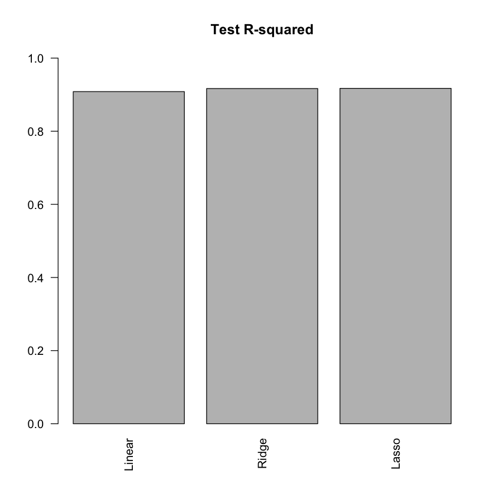

```r
test.avg <-  mean(Test[, "Apps"])

lm.test.r2 <-  1 - mean((Test[, "Apps"] - pred_line_model)^2) /
  mean((Test[, "Apps"] - test.avg)^2)

ridge.test.r2 <-  1 - mean((Test[, "Apps"] - pred_ridg_model)^2)/
  mean((Test[, "Apps"] - test.avg)^2)

lasso.test.r2 <-  1 - mean((Test[, "Apps"] - pred_lasso_model)^2)/
  mean((Test[, "Apps"] - test.avg)^2)

barplot(c(lm.test.r2, ridge.test.r2, lasso.test.r2),
        col = "gray", names.arg = c("Linear", "Ridge", "Lasso"),
        main = "Test R-squared", las=2, ylim=c(0:1))
```

Linear, Lasso, and Ridge produce comparable results. Additionally, it reduces the coefficients of other variables and shrinks the Enroll, Top25perc, F.Undergrad, P.Undergrad, Books, Personal, and S.F.Ratio variables to a precise value of zero.

From the graph its clear that every model demonstrates the test R2 of roughly 0.9. Which means all models effectively predict college applications.

# Question 2

The insurance company benchmark data set gives information on customers. Specifically, it contains 86 variables on product-usage data and socio-demographic data derived from zip area codes. There are 5,822 customers in the training set and another 4,000 in the test set. The data were collected to answer the following questions: Can you predict who will be interested in buying a caravan insurance policy and give an explanation why? Compute the OLS estimates and compare them with those obtained from the following variable-selection algorithms: Forwards Selection, Backwards Selection, Lasso regression, and Ridge regression. What methods performed the best in the prediction? (The data can be downloaded from https://kdd.ics.uci.edu/databases/tic/tic.html. )

```r
c_data = read.csv('caravan-insurance-challenge.csv')
```

```r
head(c_data,2)
```

A data.frame: 2 × 87

|  | ORIGIN <chr> | MOSTYPE <int> | MAANTHUI <int> | MGEMOMV <int> | MGEMLEEF <int> | MOSHOOFD <int> | MGODRK <int> | MGODPR <int> | MGODOV <int> | MGODGE <int> | ⋯ | APERSONG <int> | AGEZONG <int> | AWAOREG <int> | ABRAND <int> | AZEILPL <int> | APLEZIER <int> | AFIETS <int> | AINBOED <int> | ABYSTAND <int> | CARAVAN <int> |
| --- | --- | --- | --- | --- | --- | --- | --- | --- | --- | --- | --- | --- | --- | --- | --- | --- | --- | --- | --- | --- | --- |
| 1 | train | 33 | 1 | 3 | 2 | 8 | 0 | 5 | 1 | 3 | ⋯ | 0 | 0 | 0 | 1 | 0 | 0 | 0 | 0 | 0 | 0 |
| 2 | train | 37 | 1 | 2 | 2 | 8 | 1 | 4 | 1 | 4 | ⋯ | 0 | 0 | 0 | 1 | 0 | 0 | 0 | 0 | 0 | 0 |

```r
table(c_data$CARAVAN)
```

```
   0    1
9236  586
```

Checking the Frequency distribution of Caravan Policies.

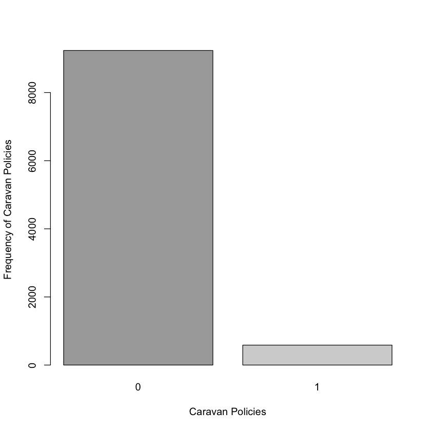

```r
barplot(table(c_data$CARAVAN), xlab= 'Caravan Policies', ylab='Frequency of Caravan Policies',col=c('dark gray','light gray'))
```

From this plot it is clear that almost all people prefer other policies over the carvan policies. Lets check who are all buying Caravan policies

Lets check the Main Types of Customers who bought Caravan Policy.

```r
cust_type = data.frame(c_data$MOSHOOFD,c_data$CARAVAN)
```

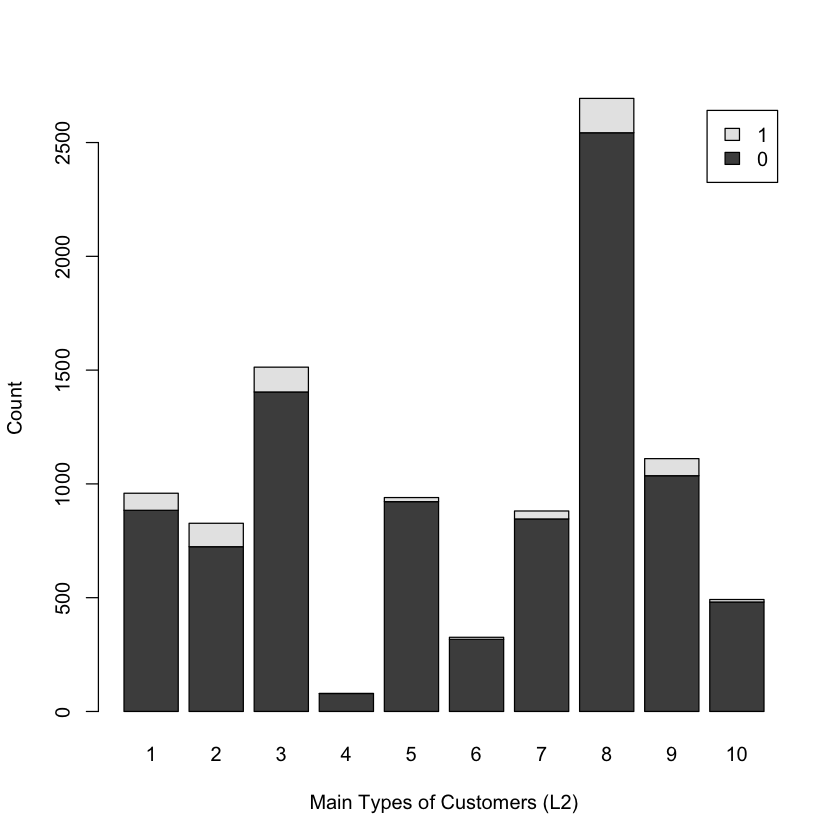

```r
barplot(table(cust_type$c_data.CARAVAN,cust_type$c_data.MOSHOOFD),legend = TRUE,xlab='Main Types of Customers (L2)',ylab='Count')
```

lets looks deep into how many of those actually bought Caravan policies.

```r
cust_type_caravan = subset(cust_type, cust_type$c_data.CARAVAN==1)
```

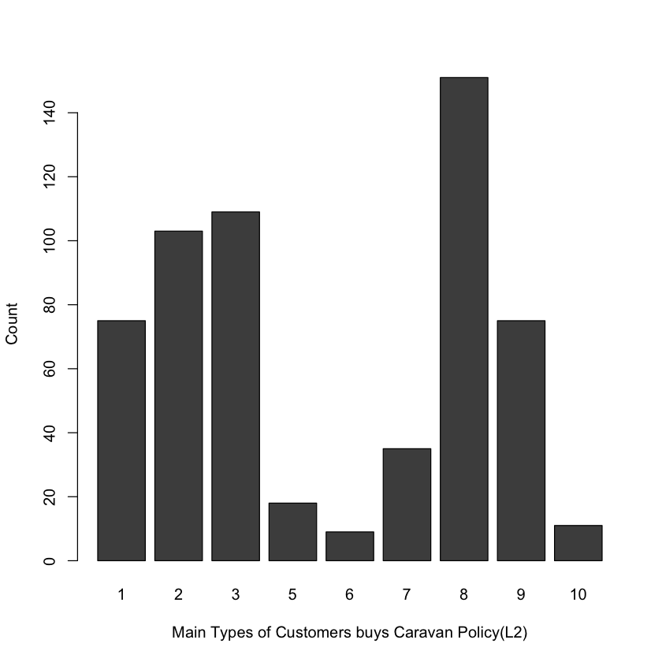

```r
barplot(table(cust_type_caravan$c_data.CARAVAN,cust_type_caravan$c_data.MOSHOOFD),xlab='Main Types of Customers buys Caravan Policy(L2)',ylab='Count ')
```

From this plot we can map that 'Family with grown ups'prefers most the Caravan Policy over the others. Also the 'Cruising Seniors' are not into this policy.

Sub Types of Customers buying policies

```r
sub_cust_type = data.frame(c_data$MOSTYPE,c_data$CARAVAN)
```

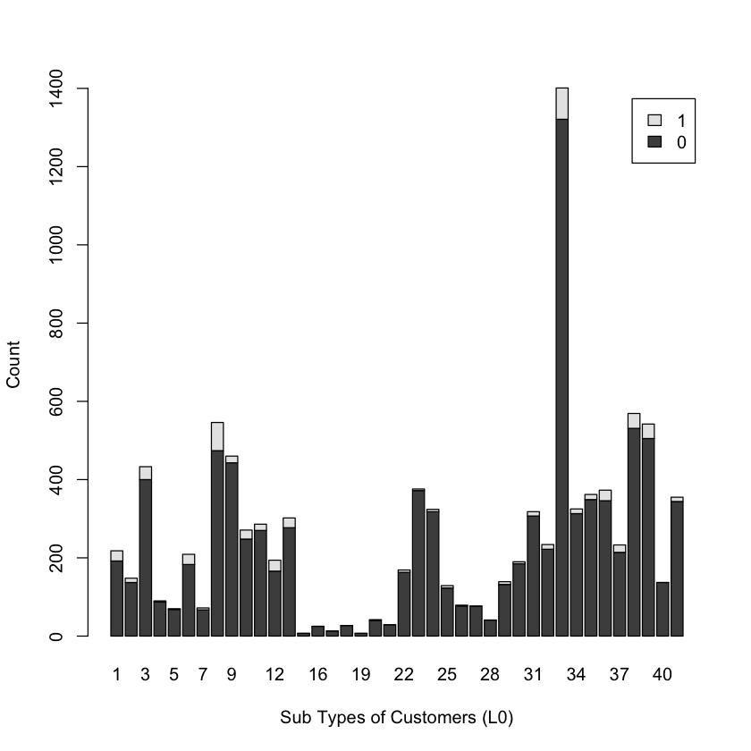

```r
barplot(table(sub_cust_type$c_data.CARAVAN,sub_cust_type$c_data.MOSTYPE),legend = TRUE,xlab='Sub Types of Customers (L0)',ylab='Count')
```

Lets look into Those who buys Caravan Policy in SUB type

```r
cust_sub_type_caravan = subset(sub_cust_type, sub_cust_type$c_data.CARAVAN==1)
```

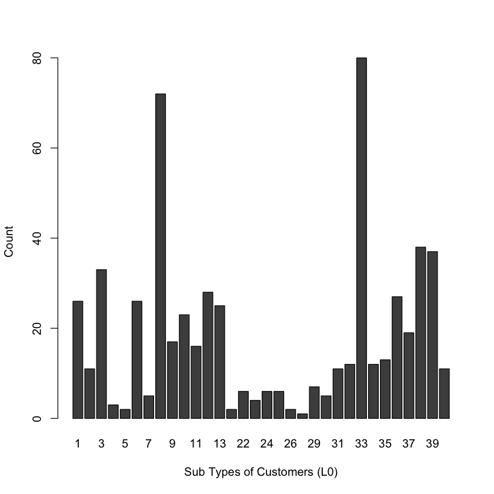

```r
barplot(table(cust_sub_type_caravan$c_data.CARAVAN,cust_sub_type_caravan$c_data.MOSTYPE),xlab='Sub Types of Customers (L0)',ylab='Count ')
```

A large difference can be seen when compared to Main type customers. Here 'Lower class large families' along with 'Middle class families' buys the caravan policies more and 'Seniors in apartments' not preffer Cravan Policy.

Plotting total number of Car Policies

```r
car_policies = data.frame(c_data$APERSAUT,c_data$CARAVAN)
```

```r
summary(car_policies)
```

```
 c_data.APERSAUT   c_data.CARAVAN
 Min.   : 0.0000   Min.   :0.00000
 1st Qu.: 0.0000   1st Qu.:0.00000
 Median : 1.0000   Median :0.00000
 Mean   : 0.5572   Mean   :0.05966
 3rd Qu.: 1.0000   3rd Qu.:0.00000
 Max.   :12.0000   Max.   :1.00000
```

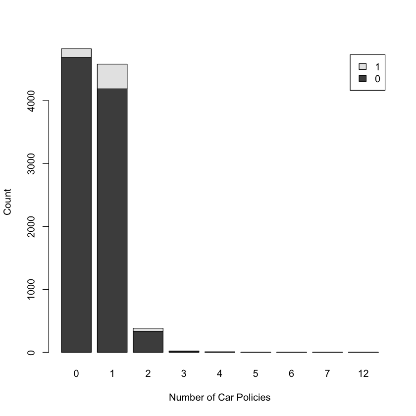

```r
barplot(table(car_policies$c_data.CARAVAN,car_policies$c_data.APERSAUT),legend = TRUE,xlab='Number of Car Policies',ylab='Count')
```

It is clear that only a few peoples are buying the cravan policy from the entire list of car policies

Those who have Caravan Policy out of differernt car plocies:

```r
car_poli_type_caravan = subset(car_policies, car_policies$c_data.CARAVAN==1)
```

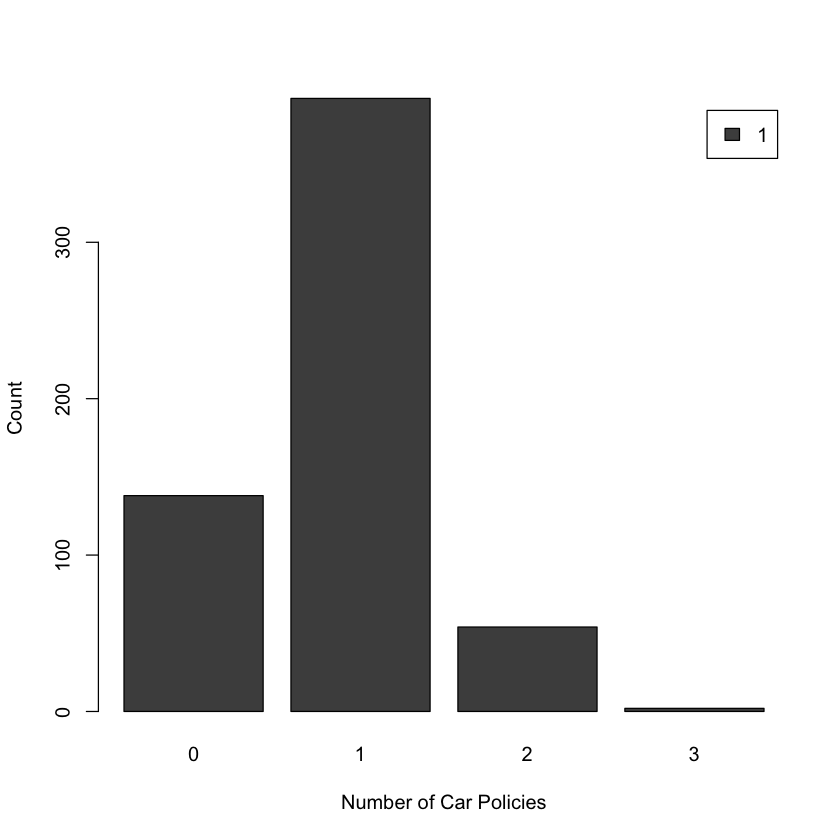

```r
barplot(table(car_poli_type_caravan$c_data.CARAVAN,car_poli_type_caravan$c_data.APERSAUT),legend = TRUE,xlab='Number of Car Policies',ylab='Count')
```

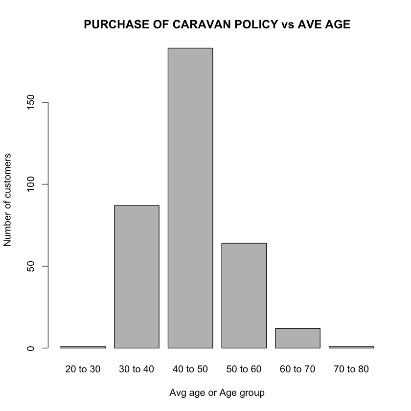

```r
age_data<-table(Caravan$MGEMLEEF[Caravan$Purchase=="Yes"])

names(age_data)=c("20 to 30","30 to 40","40 to 50","50 to 60","60 to 70","70 to 80")
barplot(age_data,col='gray',main = "PURCHASE OF CARAVAN POLICY vs AVE AGE",xlab="Avg age or Age group",ylab="Number of customers")
```

Customers of different ages are selected for the above bar plot and are mapped against those who have indicated their intent to purchase a caravan insurance policy. Customers between the ages of 40 and 50 are more likely to obtain a caravan insurance policy.

Refactoring the dataset using the dictionary provided.

```r
c_data$MOSTYPE <- factor(c_data$MOSTYPE,
                              levels=c(1:41),
                              labels=c("High Income, expensive child",
                                       "Very Important Provincials",
                                       "High status seniors",
                                       "Affluent senior apartments",
                                       "Mixed seniors",
                                       "Career and childcare",
                                       "Dinki's (Double income no kids)",
                                       "Middle class families",
                                       "Modern, complete families",
                                       "Stable family","Family starters",
                                       "Affluent young families",
                                       "Young all american family",
                                       "Junior cosmopolitans",
                                       "Senior cosmopolitans",
                                       "Students in apartments",
                                       "Fresh masters in the city",
                                       "Single youth",
                                       "Suburban youth",
                                       "Ethnically diverse",
                                       "Young urban have-nots",
                                       "Mixed apartment dwellers",
                                       "Young and rising",
                                       "Young, low educated",
                                       "Yound seniros in the city",
                                       "Own home elderly",
                                       "Seniors in apartments",
                                       "Residential elderly",
                                       "Porchless seniors: no front yard",
                                       "Religious elderly singles",
                                       "Low income catholics",
                                       "Mixed seniors2",
                                       "Lower class large families",
                                       "Large family,employed child",
                                       "Village families",
                                       "Couples with teens 'Married with children'",
                                       "Mixed small town dwellers",
                                       "Traditional families",
                                       "Large religous families",
                                       "Large family farms",
                                       "Mixed rurals"))
```

```r
c_data$MGEMLEEF <- factor(c_data$MGEMLEEF,
                     levels=c(1:6),
                     labels=c("20-30 years",
                              "30-40 years",
                              "40-50 years",
                              "50-60 years",
                              "60-70 years",
                              "70-80 years"))
```

```r
c_data$MOSHOOFD <- factor(c_data$MOSHOOFD,
                                levels=(1:10),
                                labels=c("Successful hedonists",
                                         "Driven Growers",
                                         "Average Family",
                                         "Career Loners",
                                         "Living well",
                                         "Cruising Seniors",
                                         "Retired and Religious",
                                         "Family with grown ups",
                                         "Conservatie Families",
                                         "Farmers"))
```

```r
for (i in which(colnames(c_data)=="MGODRK"):which(colnames(c_data)=="MKOOPKLA")){
  c_data[,i] <- factor(c_data[,i],
                   levels=c(0:9),
                   labels=c("0%",
                            "1-10%",
                            "11-23%",
                            "24-36%",
                            "37-49%",
                            "50-62%",
                            "63-75%",
                            "76-88%",
                            "89-99%",
                            "100%"))
}
```

```r
for (i in which(colnames(c_data)=="PWAPART"):which(colnames(c_data)=="ABYSTAND")){
  c_data[,i] <- factor(c_data[,i],
                   levels=c(0:9),
                   labels=c("0",
                            "1-49",
                            "50-99",
                            "100-199",
                            "200-499",
                            "500-999",
                            "1000-4999",
                            "5000-9999",
                            "10,000-19,999",
                            ">=20,000"))
}
```

Set class label as factor

```r
c_data$CARAVAN <- factor(c_data$CARAVAN,levels=c("0","1"))
```

### Loading test and train data

```r
install.packages('Boruta')
install.packages('randomForest')

library(MASS)
library(leaps)
library(glmnet)
library(Boruta)
library(mlbench)
library(caret)
library(randomForest)

train = read.table('ticdata2000.txt')
test = read.table('ticeval2000.txt')
```

### Linear Model

First we will run the linear model with all the 86 varibale.

```r
fit_lin_model <- lm(V86 ~ ., data = train)

pred_line_model <- predict(fit_lin_model, test)

summary(fit_lin_model)
```

```
Call:
lm(formula = V86 ~ ., data = train)

Residuals:
     Min       1Q   Median       3Q      Max
-0.67293 -0.08720 -0.04593 -0.00639  1.04628

Coefficients:
              Estimate Std. Error t value Pr(>|t|)
(Intercept)  0.7685381  0.4298406   1.788 0.073835 .
V1           0.0035209  0.0022512   1.564 0.117866
V2          -0.0072642  0.0076739  -0.947 0.343875
V3          -0.0012739  0.0071737  -0.178 0.859055
V4           0.0107473  0.0049596   2.167 0.030279 *
V5          -0.0154869  0.0101044  -1.533 0.125405
V6          -0.0056016  0.0056016  -1.000 0.317353
V7          -0.0002069  0.0060664  -0.034 0.972795
V8           0.0003569  0.0054592   0.065 0.947874
V9          -0.0030237  0.0058038  -0.521 0.602399
V10          0.0086829  0.0075479   1.150 0.250036
V11          0.0020367  0.0072008   0.283 0.777310
V12          0.0055682  0.0076295   0.730 0.465526
V13         -0.0038250  0.0065474  -0.584 0.559107
V14         -0.0050625  0.0066861  -0.757 0.448980
V15         -0.0026253  0.0069795  -0.376 0.706824
V16          0.0021357  0.0068161   0.313 0.754038
V17         -0.0048456  0.0071396  -0.679 0.497358
V18         -0.0113977  0.0073004  -1.561 0.118525
V19          0.0021884  0.0045182   0.484 0.628153
V20         -0.0004665  0.0052201  -0.089 0.928796
V21         -0.0050974  0.0050426  -1.011 0.312122
V22          0.0041254  0.0044806   0.921 0.357228
V23         -0.0006060  0.0044709  -0.136 0.892190
V24          0.0019733  0.0044532   0.443 0.657690
V25         -0.0013674  0.0051653  -0.265 0.791225
V26         -0.0031701  0.0050198  -0.632 0.527724
V27         -0.0012603  0.0044827  -0.281 0.778603
V28          0.0024879  0.0049115   0.507 0.612502
V29         -0.0008866  0.0047145  -0.188 0.850832
V30         -0.0454201  0.0376622  -1.206 0.227872
```

[output cut: 46 more lines]

```
V77         -0.0464279  0.0954471  -0.486 0.626684
V78         -0.4050642  0.1898715  -2.133 0.032938 *
V79         -0.2304561  0.1243310  -1.854 0.063852 .
V80         -0.0211374  0.0116048  -1.821 0.068593 .
V81          0.4958051  0.2815591   1.761 0.078304 .
V82          0.3633887  0.0885318   4.105 4.11e-05 ***
V83          0.0416061  0.0408644   1.018 0.308650
V84          0.0959436  0.0699079   1.372 0.169983
V85          0.1312250  0.0983836   1.334 0.182319
---
Signif. codes:  0 ‘***’ 0.001 ‘**’ 0.01 ‘*’ 0.05 ‘.’ 0.1 ‘ ’ 1

Residual standard error: 0.23 on 5736 degrees of freedom
Multiple R-squared:  0.0729,	Adjusted R-squared:  0.05916
F-statistic: 5.306 on 85 and 5736 DF,  p-value: < 2.2e-16
```

We can see most of the varibales have the p value grater tha the threhaold alpha=0.5 only few varibles are considered to be importent on OSL model. Also we can see that the Multiple R-squared is very low which means considering all the variables wont yeild goood model.

Now lets compare with the other feature selection methods.

### Forward Stepwise selection

Stepwise forward selection for variable selection.

```r
regfit.fwd=regsubsets(V86~.,data=train,nvmax =85,method ="forward")
summary(regfit.fwd)
names(summary(regfit.fwd))
```

```
Subset selection object
Call: regsubsets.formula(V86 ~ ., data = train, nvmax = 85, method = "forward")
85 Variables  (and intercept)
    Forced in Forced out
V1      FALSE      FALSE
V2      FALSE      FALSE
V3      FALSE      FALSE
V4      FALSE      FALSE
V5      FALSE      FALSE
V6      FALSE      FALSE
V7      FALSE      FALSE
V8      FALSE      FALSE
V9      FALSE      FALSE
V10     FALSE      FALSE
V11     FALSE      FALSE
```

[output cut: 506 more lines]

1. 'which'

2. 'rsq'

3. 'rss'

4. 'adjr2'

5. 'cp'

6. 'bic'

7. 'outmat'

8. 'obj'

Here we are taking the CP as the parameter as they indicate smaller amounts of unexplained error.

**(Intercept)**

0.601138904761682

**V4**

0.00960930214002603

**V7**

0.00356603487581566

**V10**

0.00508983441824055

**V16**

0.0048940385026084

**V18**

-0.00556383224310815

**V21**

-0.00855966127720788

**V35**

-0.0748299168741961

**V36**

-0.0781826417491789

**V41**

-0.0140899622666096

**V42**

0.00617512302317529

**V43**

0.00317808013663568

**V44**

0.0103281503552817

**V46**

-0.0160142592678363

**V47**

0.0103028711748965

**V57**

0.191534808013032

**V58**

0.0621013010504129

**V59**

0.0132498661906397

**V78**

-0.40555682224929

**V79**

-0.220446131902269

**V80**

-0.0218925772956851

**V82**

0.283548603876119

**V83**

0.037377965226743

**V85**

0.0701204123292275

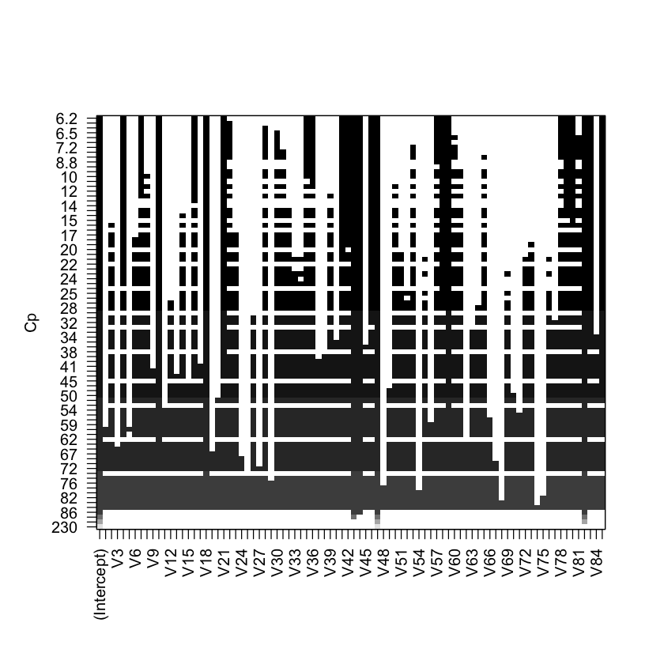

```r
plot(regfit.fwd,scale="Cp")
coef(regfit.fwd,which.min(summary(regfit.fwd)$cp))
```

We can see that 23 varibales have the least error rate and the coefficient of each is mentioned above.

```r
coef(regfit.fwd,which.min(summary(regfit.fwd)$cp))
```

**(Intercept)**

0.601138904761682

**V4**

0.00960930214002603

**V7**

0.00356603487581566

**V10**

0.00508983441824055

**V16**

0.0048940385026084

**V18**

-0.00556383224310815

**V21**

-0.00855966127720788

**V35**

-0.0748299168741961

**V36**

-0.0781826417491789

**V41**

-0.0140899622666096

**V42**

0.00617512302317529

**V43**

0.00317808013663568

**V44**

0.0103281503552817

**V46**

-0.0160142592678363

**V47**

0.0103028711748965

**V57**

0.191534808013032

**V58**

0.0621013010504129

**V59**

0.0132498661906397

**V78**

-0.40555682224929

**V79**

-0.220446131902269

**V80**

-0.0218925772956851

**V82**

0.283548603876119

**V83**

0.037377965226743

**V85**

0.0701204123292275

### Backward Stepwise Selection

```r
regfit.bwd=regsubsets(V86~.,data=train,nvmax =85,method ="backward")
summary(regfit.bwd)
```

```
Subset selection object
Call: regsubsets.formula(V86 ~ ., data = train, nvmax = 85, method = "backward")
85 Variables  (and intercept)
    Forced in Forced out
V1      FALSE      FALSE
V2      FALSE      FALSE
V3      FALSE      FALSE
V4      FALSE      FALSE
V5      FALSE      FALSE
V6      FALSE      FALSE
V7      FALSE      FALSE
V8      FALSE      FALSE
V9      FALSE      FALSE
V10     FALSE      FALSE
V11     FALSE      FALSE
```

[output cut: 506 more lines]

**(Intercept)**

0.625880433301418

**V4**

0.0105571131382716

**V6**

-0.00458041206475502

**V10**

0.00474164944480646

**V17**

-0.00688523572544399

**V18**

-0.0131574296715484

**V21**

-0.00767969572405327

**V22**

0.00318159763505442

**V28**

0.00334166028597108

**V30**

-0.0025422310526846

**V35**

-0.068207078632743

**V36**

-0.0702340214536405

**V41**

-0.0136132112542899

**V42**

0.00572036160671768

**V44**

0.0103372429597373

**V46**

-0.0162134751594655

**V47**

0.0103340827642604

**V55**

-0.0167870899520877

**V57**

0.195199280013924

**V58**

0.0626713914084347

**V59**

0.0128296564425908

**V63**

-0.0490588782500653

**V76**

0.0394482406203105

**V78**

-0.411354128519197

**V79**

-0.221856162721949

**V80**

-0.0212897263732727

**V82**

0.284396710782612

**V83**

0.0363966460768674

**V84**

0.110993313546737

**V85**

0.0730788935293407

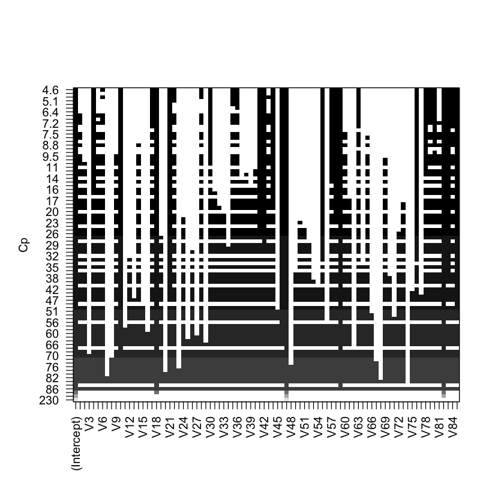

```r
plot(regfit.bwd,scale="Cp")
coef(regfit.bwd,which.min(summary(regfit.bwd)$cp))
```

Here also we use the CP varibles for the selection, as we can see in the backward the selection the minimum of CP lower that that of the forward's CP.

We can also assess fit by analysing R2 and adjusted r-squared. These are often used in along with Cp to assess model fit. Since AIC is almost similar to Cp we are not considering it here.

### Validation

```r
test['V86'] = data.frame(read.table('tictgts2000.txt'))
```

```r
set.seed(2312)
regfit.best=regsubsets(V86~.,data=train,nvmax =85, method='forward')
train.mat=model.matrix(V86~.,data=test)
val.errors =rep(NA ,85)
for(i in 1:85){
    coefi=coef(regfit.best,id=i)
    pred=train.mat[,names(coefi)]%*% coefi
    val.errors[i]= mean((test$V86-pred)^2)
}
val.errors
which.min(val.errors)
coef(regfit.best,27)
```

1. 0.0552622537380337

2. 0.0553055871872074

3. 0.0547550685919308

4. 0.0543661483738159

5. 0.0543471016674424

6. 0.054279216815238

7. 0.0541512288533905

8. 0.0542156745565218

9. 0.0540397026841397

10. 0.0540887312747479

11. 0.053997610463876

12. 0.0541149080985179

13. 0.05414061036157

14. 0.0540998393892639

15. 0.0540586364055244

16. 0.0539843203710795

17. 0.0540531004839322

18. 0.0540105638778584

19. 0.0540255848120364

20. 0.0540551025955761

21. 0.0540452708966204

22. 0.0539679146467312

23. 0.0539341167405011

24. 0.0539342709891817

25. 0.0539830297166374

26. 0.0539550765468431

27. 0.053855513285122

28. 0.0538990199877761

29. 0.0539007042774649

30. 0.0539040999996269

31. 0.0538687660468459

32. 0.0539134031622081

33. 0.0538948225070718

34. 0.053895853452482

35. 0.0539095744166763

36. 0.0538908050045711

37. 0.053864598111655

38. 0.0538749813560254

39. 0.0538980204435378

40. 0.0539153075360814

41. 0.0539188486413733

42. 0.0539123628445698

43. 0.0539234894944237

44. 0.0539313219107717

45. 0.0539119263745857

46. 0.0538897875974846

47. 0.0538870432243995

48. 0.0538660371369401

49. 0.0538722872712802

50. 0.0538692002967921

51. 0.0539112017520188

52. 0.0539101522875468

53. 0.0539084115765631

54. 0.0538979015418182

55. 0.0539048158598802

56. 0.0539239495983844

57. 0.0539221727295219

58. 0.0539241438386117

59. 0.0539315049626051

60. 0.0539366174462893

61. 0.0539419332098863

62. 0.0539292848196805

63. 0.0539176037617839

64. 0.0539032293486134

65. 0.0539033125027265

66. 0.0539268457097425

67. 0.0539277529924535

68. 0.0539287027997705

69. 0.0539279752182286

70. 0.0539357312777767

71. 0.0539229508109948

72. 0.0539655355056781

73. 0.0539638353196033

74. 0.0539674300380983

75. 0.053973368488553

76. 0.0539838782676197

77. 0.0539855372338923

78. 0.0539815318206173

79. 0.0539789007676238

80. 0.0539792866391998

81. 0.053979936773231

82. 0.0539789553207475

83. 0.053984564794373

84. 0.0539846860320122

85. 0.0539850035537475

27

**(Intercept)**

0.558970193750019

**V4**

0.011027881540155

**V7**

0.00280416327523612

**V10**

0.00442556017436228

**V16**

0.00633449764401531

**V18**

-0.00572697313315723

**V21**

-0.0070107685036152

**V22**

0.00292079293415839

**V28**

0.0032680964561068

**V30**

-0.00175681150194222

**V35**

-0.0709615008211472

**V36**

-0.0739687068800304

**V41**

-0.0143009043102958

**V42**

0.00523499495035906

**V43**

0.00274676174180258

**V44**

0.0105053714592375

**V46**

-0.0157553458091941

**V47**

0.0103342103453666

**V57**

0.193254632978446

**V58**

0.063028861467797

**V59**

0.0125772486574717

**V78**

-0.409800846071144

**V79**

-0.224589384903252

**V80**

-0.0207483423187411

**V81**

0.175792386642152

**V82**

0.278146325511686

**V83**

0.0373695402938773

**V85**

0.0700022206888448

```r
set.seed(25562)
regfit.best=regsubsets(V86~.,data=train,nvmax =85, method='backward')
train.mat=model.matrix(V86~.,data=test)
val.errors =rep(NA ,85)
for(i in 1:85){
    coefi=coef(regfit.best,id=i)
    pred=train.mat[,names(coefi)]%*% coefi
    val.errors[i]= mean((test$V86-pred)^2)
}
val.errors
which.min(val.errors)
coef(regfit.best,38)
```

1. 0.0552622537380337

2. 0.0553055871872074

3. 0.0549872883083351

4. 0.0545697369553785

5. 0.05442114058676

6. 0.0542446081711215

7. 0.0543000811136289

8. 0.0541125902745761

9. 0.0541673517687326

10. 0.0541259341453528

11. 0.0541432413268565

12. 0.0541002872670072

13. 0.0540408680019198

14. 0.0541569983095481

15. 0.05411814715563

16. 0.0541398196598276

17. 0.0540533034255398

18. 0.054026831611975

19. 0.0539575586919434

20. 0.0538874834553773

21. 0.0538804030538641

22. 0.0538888047086717

23. 0.0538411143523717

24. 0.0539087266755026

25. 0.0539384070755688

26. 0.0539252269864194

27. 0.0539197545877605

28. 0.0539770509741104

29. 0.0540123162872352

30. 0.0539694324337213

31. 0.0539510478656641

32. 0.0539856238109058

33. 0.0538905821884183

34. 0.0539263264704915

35. 0.0538901158002107

36. 0.053866430951341

37. 0.0538630573363626

38. 0.0538396551922622

39. 0.0538588034989974

40. 0.0538967604276907

41. 0.0538969999229839

42. 0.0538945029590925

43. 0.0538927256920946

44. 0.053896615938103

45. 0.0539346863131655

46. 0.0539337709933033

47. 0.0539127885154774

48. 0.0539269133349677

49. 0.0539398828730957

50. 0.0539428509189603

51. 0.0539332594668076

52. 0.0539471114256475

53. 0.0540019881744123

54. 0.0540081324800337

55. 0.0539815201060666

56. 0.0539786953728398

57. 0.0539752753197412

58. 0.0540236558462528

59. 0.0540091717510135

60. 0.0540102472002561

61. 0.054008853785728

62. 0.0540078155734321

63. 0.0540130072720956

64. 0.0540106289841049

65. 0.0539994119459069

66. 0.0539917046109905

67. 0.0539898781190415

68. 0.053990814628251

69. 0.0539905522395463

70. 0.0539980640352347

71. 0.0539968485719841

72. 0.0539903908111114

73. 0.0539846207851154

74. 0.0539837420715302

75. 0.0539832386926759

76. 0.0539816272381445

77. 0.0539849925886659

78. 0.0539812091690087

79. 0.0539827801655727

80. 0.0539833278831539

81. 0.0539811204028524

82. 0.0539841113246406

83. 0.053984564794373

84. 0.0539846860320122

85. 0.0539850035537475

38

**(Intercept)**

0.604372534651549

**V1**

0.00334639464807289

**V4**

0.011740595250189

**V5**

-0.0146763008848485

**V6**

-0.00507787652360938

**V9**

-0.00233384772010227

**V10**

0.0049798763983891

**V14**

-0.00237640567278695

**V17**

-0.00647640737536154

**V18**

-0.0127470580589107

**V21**

-0.00623054565385942

**V22**

0.00290777439110976

**V28**

0.00337168856237308

**V30**

-0.00189629000417171

**V35**

-0.0661394389990928

**V36**

-0.0687177454812051

**V41**

-0.0128742842865621

**V42**

0.00558050923632691

**V43**

0.00322259775404005

**V44**

0.0294032236850315

**V46**

-0.0161175450991365

**V47**

0.0103891363037199

**V55**

-0.0167922464996512

**V57**

0.19580165551808

**V58**

0.0630771203219954

**V59**

0.0128051584894971

**V60**

-0.183106675109576

**V63**

-0.0429332750839308

**V65**

-0.0392159862225931

**V69**

-0.0266211722831902

**V76**

0.0394670263889912

**V78**

-0.412869083606739

**V79**

-0.226110389222411

**V80**

-0.0202373439468208

**V81**

0.464696487527484

**V82**

0.27501145858197

**V83**

0.0348774925120006

**V84**

0.0927110406270069

**V85**

0.0717960860093938

Although they didn't choose the same models, in this case they both discovered the model that reduced the Cp globally.

Forward selection selected model with 27 varibales and backward selection selected model with 38 varibles.

When there are many variables to consider,forward stepwise selection might be employed instead of backward. This is so that unlike backward selection, which must take into account the entire model, forward selection begins with a null model (with no predictors) and adds variables one at a time (which includes all the predictors).

### Lasso

Choosing the best lambda

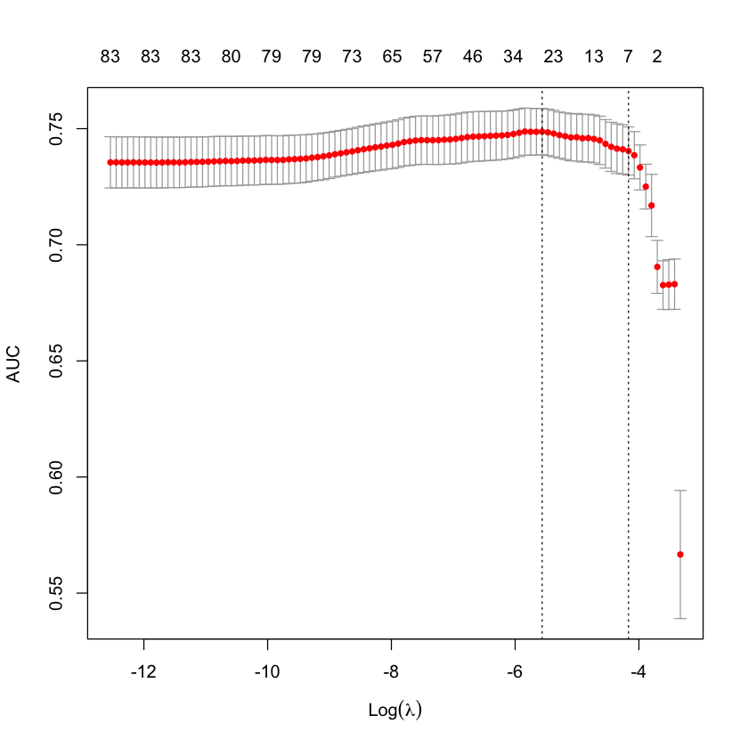

```r
x <- as.matrix(train[,-86])
y <- as.double(as.matrix(train[, 86]))

set.seed(100)
cv.lasso <- cv.glmnet(x, y, family='binomial', alpha=1, parallel=TRUE, standardize=TRUE, type.measure='auc')

plot(cv.lasso)
```

```r
cv.lasso$lambda.min
cv.lasso$lambda.1se
df_coef <- round(as.matrix(coef(cv.lasso, s=cv.lasso$lambda.min)), 2)

df_coef[df_coef[, 1] != 0, ]
```

0.00383610111498461

0.0154864064069144

**(Intercept)**

-4.67

**V4**

0.01

**V7**

0.02

**V9**

-0.01

**V10**

0.05

**V11**

-0.01

**V16**

0.04

**V18**

-0.05

**V21**

-0.11

**V22**

0.02

**V30**

-0.02

**V32**

0.04

**V40**

0.01

**V41**

-0.06

**V42**

0.05

**V43**

0.04

**V44**

0.12

**V46**

-0.1

**V47**

0.2

**V57**

0.06

**V58**

0.12

**V59**

0.1

**V73**

-0.02

**V81**

0.54

**V82**

1.77

**V83**

0.29

**V85**

0.37

### Ridge

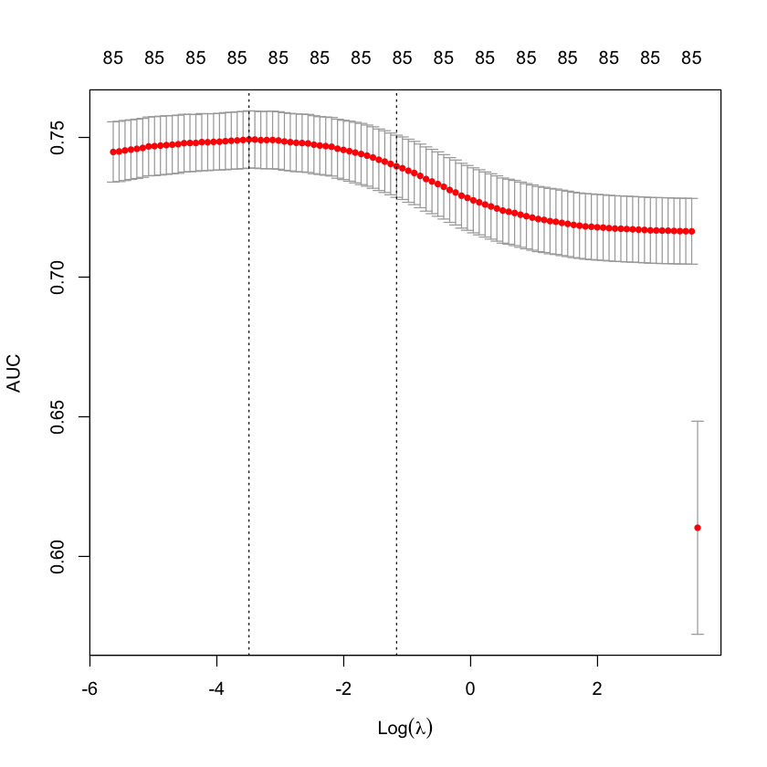

```r
x_r <- as.matrix(train[,-86])
y_r<- as.double(as.matrix(train[, 86]))

set.seed(1234)
cv.ridge <- cv.glmnet(x_r, y_r, family='binomial', alpha=0, parallel=TRUE, standardize=TRUE, type.measure='auc')

plot(cv.ridge)
```

```r
cv.ridge$lambda.min
cv.ridge$lambda.1se
df_coef <- round(as.matrix(coef(cv.ridge, s=cv.ridge$lambda.min)), 2)

df_coef[df_coef[, 1] != 0, ]
```

0.030400445299817

0.311157988439072

**(Intercept)**

-4.72

**V2**

-0.09

**V3**

-0.02

**V4**

0.09

**V5**

-0.01

**V6**

-0.04

**V7**

0.02

**V8**

0.03

**V9**

-0.02

**V10**

0.03

**V11**

-0.04

**V12**

-0.01

**V13**

-0.01

**V14**

-0.01

**V15**

0.01

**V16**

0.05

**V17**

0.01

**V18**

-0.04

**V19**

0.01

**V20**

0.01

**V21**

-0.1

**V22**

0.04

**V23**

-0.01

**V24**

0.01

**V25**

0.01

**V27**

-0.01

**V28**

0.02

**V29**

-0.03

**V30**

-0.01

**V31**

0.01

**V32**

0.04

**V34**

-0.02

**V35**

0.01

**V36**

-0.01

**V37**

-0.01

**V38**

0.02

**V39**

0.01

**V40**

0.05

**V41**

-0.11

**V42**

0.04

**V43**

0.04

**V44**

0.09

**V45**

-0.03

**V46**

-0.09

**V47**

0.1

**V48**

-0.02

**V49**

-0.02

**V50**

-0.1

**V51**

0.13

**V53**

-0.15

**V54**

-0.05

**V55**

-0.05

**V56**

-0.07

**V57**

0.19

**V58**

0.19

**V59**

0.07

**V60**

-0.28

**V61**

0.13

**V62**

0.27

**V63**

-0.18

**V64**

0.05

**V65**

0.12

**V67**

-0.28

**V68**

0.29

**V69**

-0.16

**V70**

0.06

**V71**

-0.33

**V72**

0.05

**V73**

-0.15

**V74**

-0.22

**V75**

-0.17

**V76**

0.13

**V77**

-0.18

**V78**

-0.03

**V79**

0.03

**V80**

0.04

**V81**

1.29

**V82**

1.37

**V83**

0.21

**V84**

0.24

**V85**

0.34

# Question 3

ESL textbook exercise 2.8 modified: Compare the classification performance of linear regression and k-nearest neighbor classification on the zipcode data. In particular, consider only the 7’s and 9’s for this problem, and k = 1, 3, 5, 7, 9, 11, 13,15. Show the test error for each choice of k. Describe your results – are you surprised by the differences in performance?

The zipcode data is available https://hastie.su.domains/ElemStatLearn/ in the “Data” tab. The data can be obtained as test/training and/or by number.

```r
set.seed(284)
```

loading the data

```r
train_data = read.table('zip.train')
```

```r
head(train_data,5)
```

A data.frame: 5 × 257

|  | V1 <dbl> | V2 <dbl> | V3 <dbl> | V4 <dbl> | V5 <dbl> | V6 <dbl> | V7 <dbl> | V8 <dbl> | V9 <dbl> | V10 <dbl> | ⋯ | V248 <dbl> | V249 <dbl> | V250 <dbl> | V251 <dbl> | V252 <dbl> | V253 <dbl> | V254 <dbl> | V255 <dbl> | V256 <dbl> | V257 <dbl> |
| --- | --- | --- | --- | --- | --- | --- | --- | --- | --- | --- | --- | --- | --- | --- | --- | --- | --- | --- | --- | --- | --- |
| 1 | 6 | -1 | -1 | -1 | -1.000 | -1.000 | -1.000 | -1.000 | -0.631 | 0.862 | ⋯ | 0.304 | 0.823 | 1.000 | 0.482 | -0.474 | -0.991 | -1.000 | -1.000 | -1.000 | -1 |
| 2 | 5 | -1 | -1 | -1 | -0.813 | -0.671 | -0.809 | -0.887 | -0.671 | -0.853 | ⋯ | -0.671 | -0.671 | -0.033 | 0.761 | 0.762 | 0.126 | -0.095 | -0.671 | -0.828 | -1 |
| 3 | 4 | -1 | -1 | -1 | -1.000 | -1.000 | -1.000 | -1.000 | -1.000 | -1.000 | ⋯ | -1.000 | -1.000 | -1.000 | -0.109 | 1.000 | -0.179 | -1.000 | -1.000 | -1.000 | -1 |
| 4 | 7 | -1 | -1 | -1 | -1.000 | -1.000 | -0.273 | 0.684 | 0.960 | 0.450 | ⋯ | -0.318 | 1.000 | 0.536 | -0.987 | -1.000 | -1.000 | -1.000 | -1.000 | -1.000 | -1 |
| 5 | 3 | -1 | -1 | -1 | -1.000 | -1.000 | -0.928 | -0.204 | 0.751 | 0.466 | ⋯ | 0.466 | 0.639 | 1.000 | 1.000 | 0.791 | 0.439 | -0.199 | -0.883 | -1.000 | -1 |

```r
test_data = read.table('zip.test')
```

```r
head(test_data,5)
```

A data.frame: 5 × 257

|  | V1 <int> | V2 <dbl> | V3 <dbl> | V4 <dbl> | V5 <dbl> | V6 <dbl> | V7 <dbl> | V8 <dbl> | V9 <dbl> | V10 <dbl> | ⋯ | V248 <dbl> | V249 <dbl> | V250 <dbl> | V251 <dbl> | V252 <dbl> | V253 <dbl> | V254 <dbl> | V255 <dbl> | V256 <dbl> | V257 <dbl> |
| --- | --- | --- | --- | --- | --- | --- | --- | --- | --- | --- | --- | --- | --- | --- | --- | --- | --- | --- | --- | --- | --- |
| 1 | 9 | -1 | -1 | -1 | -1.000 | -1.0 | -0.948 | -0.561 | 0.148 | 0.384 | ⋯ | -1.000 | -0.908 | 0.430 | 0.622 | -0.973 | -1.000 | -1 | -1 | -1 | -1 |
| 2 | 6 | -1 | -1 | -1 | -1.000 | -1.0 | -1.000 | -1.000 | -1.000 | -1.000 | ⋯ | -1.000 | -1.000 | -1.000 | -1.000 | -1.000 | -1.000 | -1 | -1 | -1 | -1 |
| 3 | 3 | -1 | -1 | -1 | -0.593 | 0.7 | 1.000 | 1.000 | 1.000 | 1.000 | ⋯ | 1.000 | 0.717 | 0.333 | 0.162 | -0.393 | -1.000 | -1 | -1 | -1 | -1 |
| 4 | 6 | -1 | -1 | -1 | -1.000 | -1.0 | -1.000 | -1.000 | -1.000 | -1.000 | ⋯ | -1.000 | -1.000 | -1.000 | -1.000 | -1.000 | -1.000 | -1 | -1 | -1 | -1 |
| 5 | 6 | -1 | -1 | -1 | -1.000 | -1.0 | -1.000 | -1.000 | -0.858 | -0.106 | ⋯ | 0.901 | 0.901 | 0.901 | 0.290 | -0.369 | -0.867 | -1 | -1 | -1 | -1 |

Subset the train & test data to 7's and 9's only. Then we convert to our desired variables.

```r
train <- train_set[train_set[,1] %in% c(7, 9),]
test <- test_set[test_set[,1] %in% c(7, 9),]
vars <- c("V1", "V3", "V5", "V7", "V9", "V11", "V13","V15")
train <- train[,vars]
test <- test[,vars]
```

## Linear Model

```r
linear_model <- lm(train[,1]~., data=train[,-1])
weighted_average <- predict(linear_model, test[,2:8])
lin_pred_vals <- ifelse(weighted_average>2.5, 7, 9)
lin_error_rate <- mean(lin_pred_vals!=test[,1])
```

```r
print(paste("Linear model error rate:",lin_error_rate))
```

```
[1] "Linear model error rate: 0.546296296296296"
```

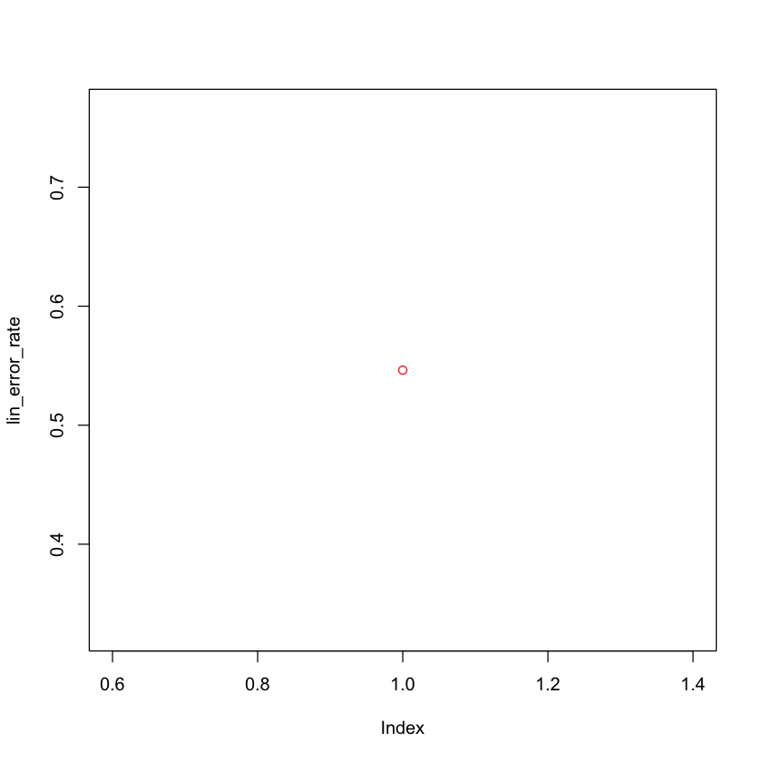

```r
plot(lin_error_rate, col='red')
```

## kNN Model

loading libraries for kNN

```r
install.packages("class")
library(class)
```

By selecting an ideal K by crossvalidation, we might reduce the error rate.

```
[1] "kNN error rate when K = 1 is 0.228395061728395"
[1] "kNN error rate when K = 3 is 0.212962962962963"
[1] "kNN error rate when K = 5 is 0.191358024691358"
[1] "kNN error rate when K = 7 is 0.166666666666667"
[1] "kNN error rate when K = 9 is 0.160493827160494"
[1] "kNN error rate when K = 11 is 0.160493827160494"
[1] "kNN error rate when K = 13 is 0.151234567901235"
[1] "kNN error rate when K = 15 is 0.157407407407407"
```

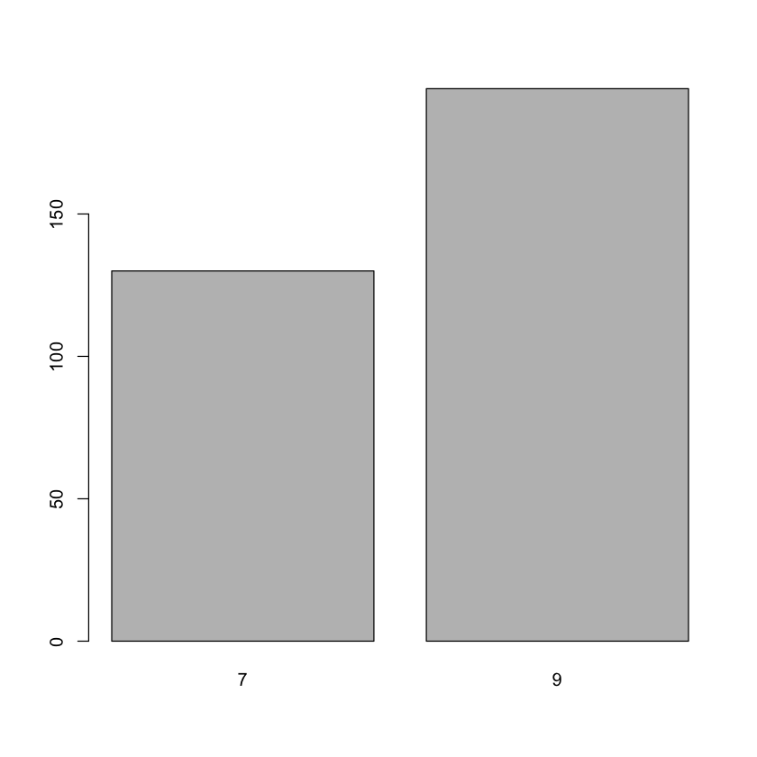

```r
k_vals = c(1, 3, 5, 7, 9, 11, 13, 15)

for (i in 1:length(k_vals)){
                knn_pred_vals <- knn(train[,2:8], test[,2:8], train[,1], k=i)
                knn_error_rate <- mean(knn_pred_vals!=test[,1])
                print(paste("kNN error rate when K =",k_vals[i],"is",knn_error_rate))
}
plot(knn_pred_vals)
```

It is surprising that the test error rates tend to fall as the number of neighbors increases.